# [EM1413] - Health Data Science

MEPS healthcare access and disparities analysis

Alessia Berruti, Noemi Gambini, Irene Romani

2026-06-11

# Problem Definition

In this project, we aim to investigate the existence of a systematic association between socio-economic determinants, specifically insurance coverage and income levels, and the actual accessibility of healthcare services. We seek to determine if structural barriers create a condition of “hidden exclusion,” in which individuals with greater healthcare needs may experience reduced access to healthcare services despite their clinical needs.

# Abstract

After inspecting the Medical Expenditure Panel Survey (MEPS) dataset and understanding its nature, we decided to examine whether unequal access to care makes a measurable impact on healthcare utilization and health management across the U.S. population. Furthermore, we attempted to identify which demographic and economic sections face the strongest barriers and how these barriers suppress the utilization of essential services.

The first part of our analysis is dedicated to data cleaning and exploration. We handled MEPS-specific non-response codes, treated them as missing values, and dropped observations that lacked significance for our research scope. We also transformed continuous variables into categorical ones to allow for a more informative interpretation of socio-economic disparities.

Data visualization is focused on our main elements of interest: insurance status, income, and access barriers. Furthermore, we performed exploratory analysis by observing the geographical distribution of indicators across regions to detect potential spatial disparities.

We propose three core statistical models to validate our hypotheses: a Logistic Regression to identify the predictors of access barriers, a Negative Binomial Regression to analyze healthcare utilization, and a Generalized Linear Mixed Model (GLMM) to investigate whether geographic context or insurance clustering adds explanatory power beyond individual characteristics.

# Setup and Data Loading

The analysis begins with the configuration of the R environment; once the necessary libraries have been loaded, we proceed to upload and prepare the Medical Expenditure Panel Survey (MEPS HC-216) dataset, that is a comprehensive public health survey designed to collect data on the cost and use of healthcare and health insurance coverage across the United States.

MEPS uses a complex, multistage probability sampling design. Each respondent carries a sampling weight (`PERWT19F`) representing the number of U.S. civilians they represent in the population. Two additional variables, `VARSTR` (stratum) and `VARPSU` (primary sampling unit), are required for correct variance estimation. In the Exploratory Data Analysis section that follows, we use the `survey` package to produce population-representative estimates. For the regression models (Logistic, Negative Binomial, and GLMM), design-based inference is limited by software constraints. However, we verify that normalized weights are not significant predictors when included as fixed effects. Therefore, unweighted models yield essentially equivalent population-level inference.

```r
library(tidyverse)
library(dplyr)
library(ggplot2)
library(gridExtra)
library(kableExtra)
library(knitr)
library(skimr)
library(corrplot)
library(scales)
library(haven)
library(survey)
library(lme4) # GLMM
library(MASS) # glm.nb
library(AER) # dispersiontest
library(lmtest) # lrtest
library(pROC) # ROC / AUC
library(sjPlot) # plot_model
library(parameters) # random_parameters
library(MuMIn) # r.squaredGLMM
library(broom.mixed) # tidy for mixed models
library(ggeffects) # marginal effects

meps_raw <- read_dta("h216.dta")
```

```
## Raw dataset dimensions:  28512  observations and  1447  variables
```

## Data Cleaning and Variable Construction

```r
meps <- meps_raw

# Handle MEPS negative codes
meps[meps == -1 | meps == -7 | meps == -8 | meps == -9] <- NA

# Demographics
meps$age <- meps$AGE19X
meps$age_group <- cut(meps$age,
                      breaks = c(0, 17, 34, 49, 64, Inf),
                      labels = c("0-17", "18-34", "35-49", "50-64", "65+"))
meps$sex <- factor(meps$SEX, levels = 1:2, labels = c("Male", "Female"))
meps$race_eth <- case_when(
  meps$HISPANX == 1 ~ "Hispanic",
  meps$RACEV1X == 1 & meps$HISPANX == 2 ~ "White Non-Hispanic",
  meps$RACEV1X == 2 & meps$HISPANX == 2 ~ "Black Non-Hispanic",
  meps$RACEV1X == 3 & meps$HISPANX == 2 ~ "Asian Non-Hispanic",
  TRUE ~ "Other/Mixed") %>%
  factor(levels = c("White Non-Hispanic", "Black Non-Hispanic", "Hispanic",
                    "Asian Non-Hispanic", "Other/Mixed"))

meps$educ_yrs <- meps$EDUCYR
meps$educ_cat <- cut(meps$educ_yrs,
                     breaks = c(-Inf, 8, 11, 12, 15, Inf),
                     labels = c("< Some HS", "Some HS", "HS Grad", "Some College", "College+"))
meps$marital <- factor(meps$MARRY19X, levels = 1:5, labels = c("Married", "Widowed",
                                                               "Divorced", "Separated",
                                                               "Never Married"))

# Insurance and Income
meps$ins_status <- factor(meps$INSCOV19, levels = 1:3, labels = c("Any Private", "Public Only",
                                                                  "Uninsured"))
meps$medicaid <- factor(meps$MCAID19X, levels = 1:2, labels = c("Yes", "No"))
meps$medicare <- factor(meps$MCARE19X, levels = 1:2, labels = c("Yes", "No"))
meps$uninsured <- ifelse(meps$ins_status == "Uninsured", 1, 0)

meps$povcat <- factor(meps$POVCAT19, levels = 1:5,
                      labels = c("Poor (<100% FPL)","Near Poor (100-124%)",
                                 "Low Income (125-199%)", "Middle Income (200-399%)",
                                 "High Income (400%+)"))
meps$low_income <- ifelse(meps$POVCAT19 %in% c(1, 2, 3), 1, 0)

# Health status and chronic conditions
meps$health_gen <- factor(meps$RTHLTH53, levels = 1:5, labels = c("Excellent", "Very Good",
                                                                  "Good", "Fair", "Poor"))
meps$health_ment <- factor(meps$MNHLTH53, levels = 1:5, labels = c("Excellent", "Very Good",
                                                                   "Good", "Fair", "Poor"))
meps$poor_health <- ifelse(meps$RTHLTH53 %in% c(4, 5), 1, 0)

meps$hypertension <- ifelse(meps$HIBPDX == 1, 1, 0)
meps$diabetes <- ifelse(meps$DIABDX_M18 == 1, 1, 0)
meps$heart_dis <- ifelse(meps$CHDDX == 1, 1, 0)
meps$high_chol <- ifelse(meps$CHOLDX == 1, 1, 0)
meps$arthritis <- ifelse(meps$ARTHDX == 1, 1, 0)
meps$n_chronic <- rowSums(meps[, c("hypertension", "diabetes", "heart_dis", "high_chol",
                                   "arthritis")], na.rm = TRUE)
meps$any_chronic <- ifelse(meps$n_chronic > 0, 1, 0)

# Access barriers and utilization
meps$delayed_care <- ifelse(meps$DLAYCA42 == 1, 1, 0)
meps$unafford_care <- ifelse(meps$AFRDCA42 == 1, 1, 0)
meps$delayed_dental<- ifelse(meps$DLAYDN42 == 1, 1, 0)
meps$any_barrier <- ifelse(meps$delayed_care == 1 | meps$unafford_care == 1, 1, 0)

meps$office_visits <- meps$OBTOTV19
meps$er_visits <- meps$ERTOT19
meps$ip_stays <- meps$IPDIS19
meps$total_visits <- meps$office_visits + meps$er_visits
meps$total_exp <- meps$TOTEXP19
meps$oop_exp <- meps$TOTSLF19

meps$region <- factor(meps$REGION19, levels = 1:4, labels = c("Northeast", "Midwest", "South",
                                                              "West"))

# Survey design variables
meps$perwt  <- meps$PERWT19F
meps$varstr <- meps$VARSTR
meps$varpsu <- meps$VARPSU

# Restrict to adults
meps_adults <- meps %>%
  filter(age >= 18) %>%
  drop_na(sex, age_group, ins_status, povcat, race_eth, health_gen, office_visits, delayed_care,
          any_barrier, perwt, varstr, varpsu)

# Normalized weights
meps_adults$perwt_norm <- meps_adults$perwt / mean(meps_adults$perwt)
```

```
## Adults in final dataset: 21367
```

```
## Represented US population (weighted N): 248,750,966
```

```r
options(survey.lonely.psu = "adjust")

meps_svy <- svydesign(ids = ~varpsu, strata = ~varstr, weights = ~perwt, data = meps_adults,
                      nest = TRUE)
```

# Exploratory Data Analysis

## Age Distribution

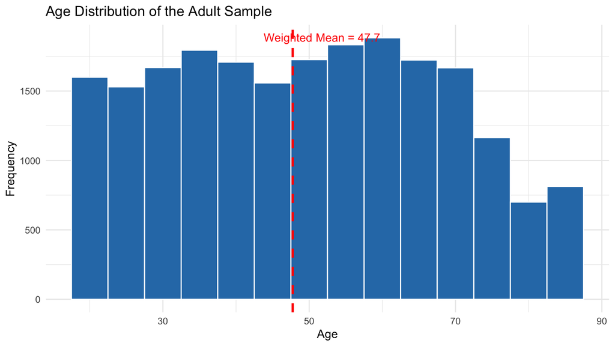

The age distribution of the adult sample is relatively flat across the working-age population, with a weighted mean of 47.7 years. The distribution shows a moderate concentration between ages 45 and 70.

## Insurance Coverage

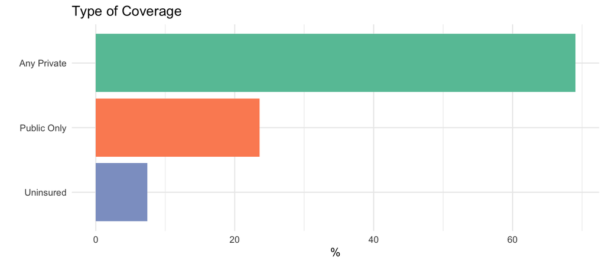

Insurance coverage in the U.S. adult population is dominated by private plans, which cover approximately 69% of adults. Public-only coverage accounts for roughly 23.6%, while the uninsured represent approximately 7.4% of the adult population. Although the uninsured share is the smallest of the three groups, it represents a non-trivial segment of the population.

## Income Distribution

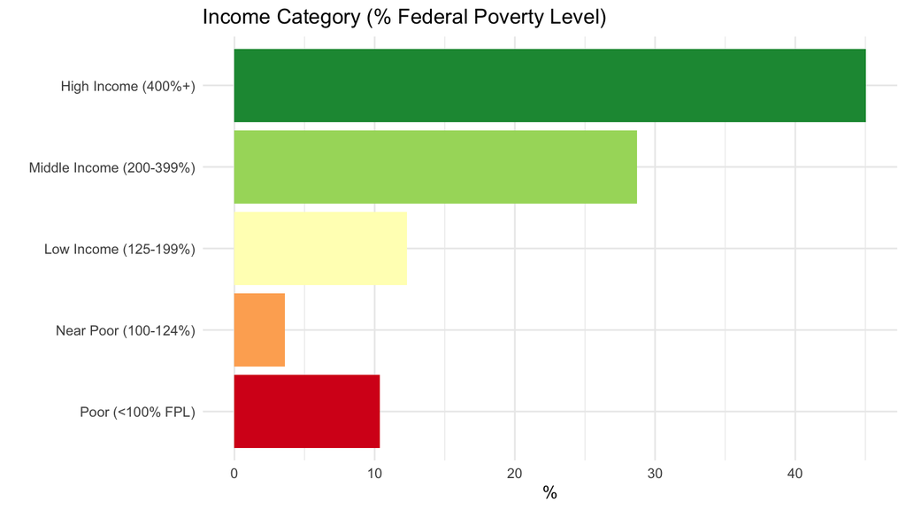

The income distribution reveals that over 45% of adults fall in the High Income bracket, while the combined low-income population, those below 200% FPL, accounts for approximately 26% of the sample.

## Racial and Ethnic Diversity

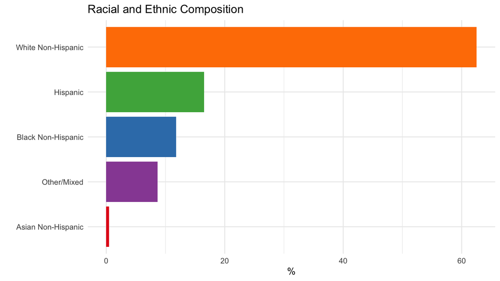

The sample exhibits a diverse racial and ethnic composition, with White Non-Hispanic adults constituting the clear majority at approximately 63%, followed by Hispanic (17%) and Black Non-Hispanic (12%) adults. Asian Non-Hispanic respondents represent a small share.

## Gender Disparities

```r
gender_tbl <- svyby( ~any_barrier + delayed_care + unafford_care + office_visits +
    er_visits + poor_health + any_chronic + uninsured,
  ~sex, meps_svy, svymean, na.rm = TRUE
) %>%
  as.data.frame() %>%
  mutate(
    `% Any Barrier`= round(any_barrier * 100, 1),
    `% Delayed Care`= round(delayed_care * 100, 1),
    `% Unafford. Care`= round(unafford_care * 100, 1),
    `Avg Office Visits`= round(office_visits, 2),
    `Avg ER Visits`= round(er_visits, 2),
    `% Poor Health`= round(poor_health * 100, 1),
    `% Any Chronic`= round(any_chronic * 100, 1),
    `% Uninsured`= round(uninsured * 100, 1)
  ) %>%
  dplyr::select(sex, `% Any Barrier`, `% Delayed Care`, `% Unafford. Care`, `Avg Office Visits`, `Avg ER Visits`,
                `% Poor Health`, `% Any Chronic`, `% Uninsured`)

knitr::kable(gender_tbl,
             caption = "Weighted Access and Utilization Indicators by Gender") %>%
  kable_styling(bootstrap_options = c("striped", "hover"))
```

Weighted Access and Utilization Indicators by Gender

|  | sex | % Any Barrier | % Delayed Care | % Unafford. Care | Avg Office Visits | Avg ER Visits | % Poor Health | % Any Chronic | % Uninsured |
| --- | --- | --- | --- | --- | --- | --- | --- | --- | --- |
| Male | Male | 9.4 | 8.3 | 5.0 | 5.93 | 0.19 | 11.5 | 49.6 | 9.3 |
| Female | Female | 11.6 | 10.5 | 6.5 | 8.56 | 0.26 | 12.5 | 49.4 | 5.7 |

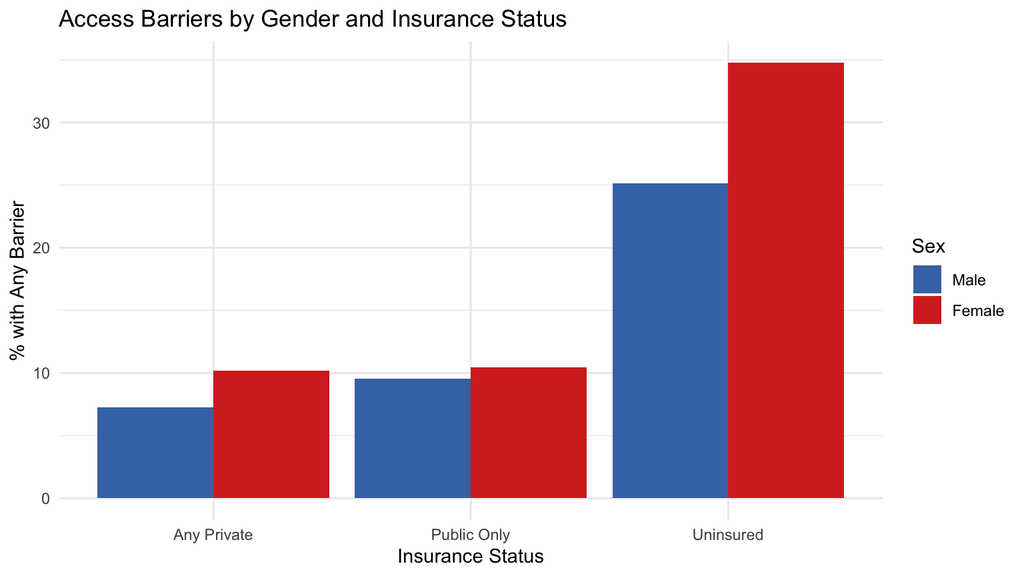

```r
gender_ins_barrier <- svyby(~any_barrier, ~sex + ins_status, meps_svy,svymean, na.rm = TRUE) %>%
  as.data.frame() %>%
  mutate(pct_barrier = any_barrier * 100)

ggplot(gender_ins_barrier,
       aes(x = ins_status, y = pct_barrier, fill = sex)) +
  geom_col(position = "dodge") +
  scale_fill_manual(values = c("Male" = "#4575B4", "Female" = "#D73027"), name = "Sex") +
  labs(title = "Access Barriers by Gender and Insurance Status",
       x = "Insurance Status", y = "% with Any Barrier") +
  theme_minimal()
```

When access barriers are examined jointly by gender and insurance status, a consistent pattern emerges: women report higher barrier rates than men within every insurance category. The gap is most pronounced among the uninsured, where both sexes face the highest absolute barrier rates. Among privately insured individuals, the reference group with the best coverage, the female excess in barriers remains visible, suggesting that gender-related disparities in access are not fully explained by insurance coverage alone.

Significance Tests

| Variable | Test | Statistic | P_Value | Significance |
| --- | --- | --- | --- | --- |
| Any Barrier | Chi-Square | 23.098 | 0 | (p < 0.001) |
| Delayed Care | Chi-Square | 23.520 | 0 | (p < 0.001) |
| Office Visits | T-Test | 12.069 | 0 | (p < 0.001) |

To confirm that these patterns are not due to sampling variability,significance tests were conducted. The chi-square test for any access barrier (p < 0.001) and for delayed care (p < 0.001) both indicate highly significant gender differences. The t-test for office visit counts (t = 12.07, p < 0.001) confirms that the utilization gap between women and men is statistically robust after accounting for the stratified sampling design.

## Health Status and Chronic Conditions

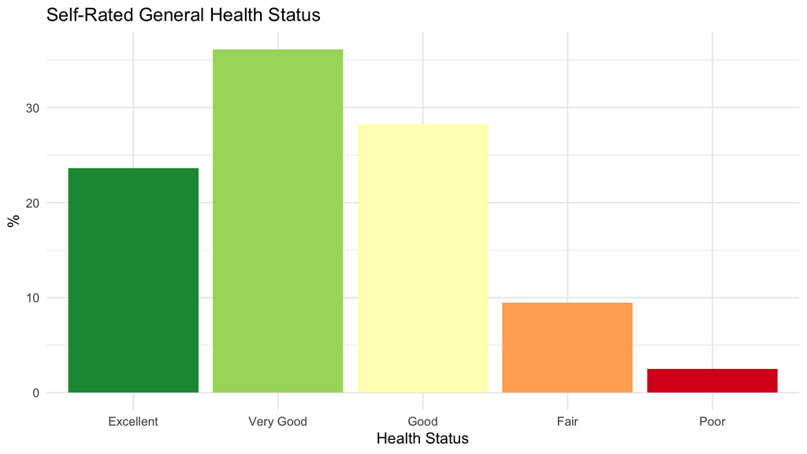

```r
health_wtd <- svymean(~health_gen, meps_svy, na.rm = TRUE) %>%
  as.data.frame() %>%
  rownames_to_column("health_gen") %>%
  mutate(health_gen = gsub("health_gen", "", health_gen),
         pct = mean * 100,
         health_gen = factor(health_gen,
                              levels = c("Excellent", "Very Good", "Good", "Fair", "Poor")))

ggplot(health_wtd, aes(x = health_gen, y = pct, fill = health_gen)) +
  geom_col(show.legend = FALSE) +
  scale_fill_manual(values = c("Excellent" = "#1a9641", "Very Good"= "#a6d96a", "Good"= "#ffffbf",
                                "Fair"= "#fdae61", "Poor"= "#d7191c")) +
  labs(title = "Self-Rated General Health Status",x = "Health Status", y = "%") +
  theme_minimal()
```

The self-rated health distribution is left-skewed in a favorable direction: the majority of U.S. adults rate their health as Very Good or Good, while only about 12% report Fair or Poor health.

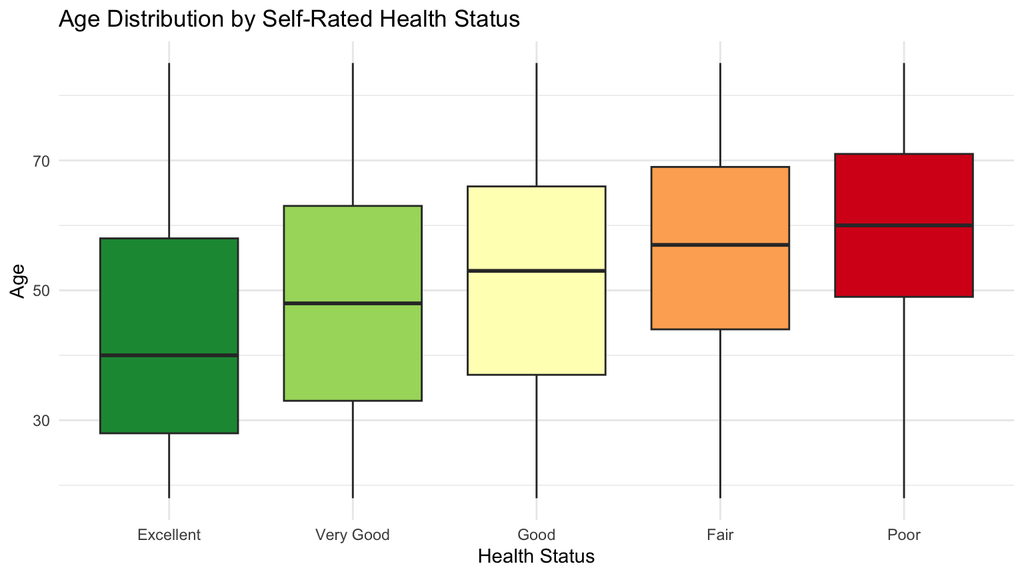

```r
meps_adults %>%
  filter(!is.na(health_gen)) %>%
  mutate(health_gen = factor(health_gen,
                              levels = c("Excellent", "Very Good", "Good", "Fair", "Poor"))) %>%
  ggplot(aes(x = health_gen, y = age, fill = health_gen)) +
  geom_boxplot(outlier.alpha = 0.2) +
  scale_fill_manual(values = c("Excellent"= "#1a9641","Very Good" = "#a6d96a","Good"= "#ffffbf",
                                "Fair"= "#fdae61","Poor"= "#d7191c")) +
  labs(title = "Age Distribution by Self-Rated Health Status",
       x = "Health Status", y = "Age") +
  theme_minimal() +
  theme(legend.position = "none")
```

The relationship between age and self-rated health is clearly visible: the median age rises progressively as health status worsens, from approximately 40 years among those reporting Excellent health to over 60 among those in Poor health.

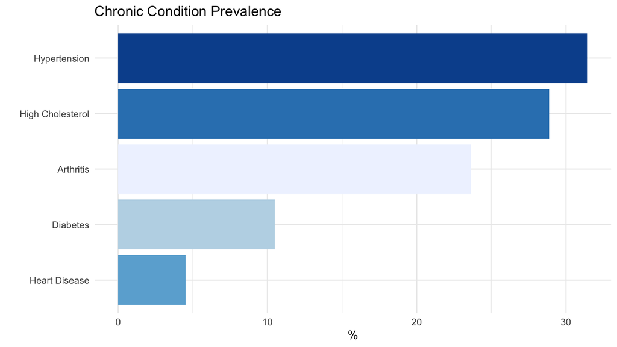

```r
chronic_vars   <- c("hypertension", "high_chol", "arthritis", "diabetes", "heart_dis")
chronic_labels <- c("Hypertension", "High Cholesterol", "Arthritis", "Diabetes", "Heart Disease")

chronic_prev <- svymean(reformulate(chronic_vars), meps_svy, na.rm = TRUE) %>%
  as.data.frame() %>%
  rownames_to_column("Condition") %>%
  mutate(Condition  = chronic_labels, Prevalence = mean * 100)

ggplot(chronic_prev,
       aes(x = reorder(Condition, Prevalence), y = Prevalence, fill = Condition)) +
  geom_col(show.legend = FALSE) +
  coord_flip() +
  scale_fill_brewer(palette = "Blues") +
  labs(title = "Chronic Condition Prevalence", x = "", y = "%") +
  theme_minimal()
```

Hypertension is the most prevalent chronic condition in the adult population, affecting approximately 30% of individuals, followed by high cholesterol and arthritis. Diabetes and heart disease are less prevalent but clinically significant. These five conditions together constitute the chronic burden variable (`n_chronic`) used in subsequent regression models.

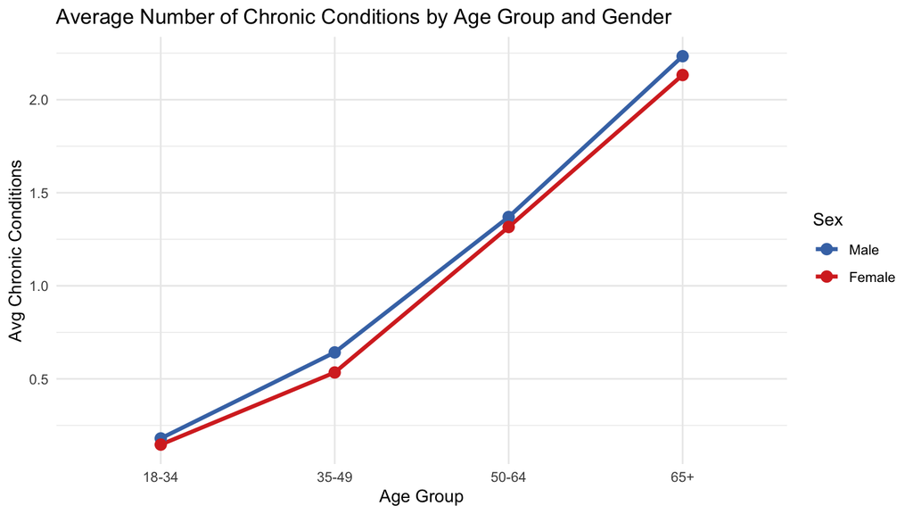

```r
chronic_age_sex <- svyby(~n_chronic, ~age_group + sex,
                          meps_svy, svymean, na.rm = TRUE) %>%
                          as.data.frame()

ggplot(chronic_age_sex,
       aes(x = age_group, y = n_chronic, color = sex, group = sex)) +
  geom_line(size = 1.2) +
  geom_point(size = 3) +
  scale_color_manual(values = c("Male" = "#4575B4", "Female" = "#D73027"), name = "Sex") +
  labs(title = "Average Number of Chronic Conditions by Age Group and Gender",
       x = "Age Group", y = "Avg Chronic Conditions") +
  theme_minimal()
```

The chronic disease burden rises sharply with age for both sexes, confirming that aging is the dominant driver of health needs in the sample. The average number of chronic conditions increases steadily across all age groups, exceeding two conditions per person among adults aged 65 and older. While small gender differences emerge in later life, these differences remain modest.  
This graph is important because it explains the strong increase in healthcare utilization with age: as chronic conditions accumulate, so does the need for medical care.

## Access Barriers by Insurance Status and Income

Having established the sample characteristics and health profile, we now examine the central variable of interest: the prevalence of access barriers across structural dimensions.

```r
barrier_tbl <- svyby(~delayed_care + unafford_care + any_barrier,
                     ~ins_status, meps_svy, svymean, na.rm = TRUE
) %>%
  as.data.frame() %>%
  transmute(`Insurance Status` = ins_status,`% Delayed Care`   = round(delayed_care  * 100, 1),`% Cannot Afford`  = round(unafford_care * 100, 1),`% Any Barrier`    = round(any_barrier   * 100, 1))

knitr::kable(barrier_tbl,
             caption = "Access Barriers by Insurance Status — Weighted (%)") %>%
  kable_styling(bootstrap_options = c("striped", "hover"))
```

Access Barriers by Insurance Status — Weighted (%)

|  | Insurance Status | % Delayed Care | % Cannot Afford | % Any Barrier |
| --- | --- | --- | --- | --- |
| Any Private | Any Private | 8.0 | 4.1 | 8.7 |
| Public Only | Public Only | 8.4 | 6.9 | 10.1 |
| Uninsured | Uninsured | 25.8 | 18.1 | 28.9 |

Analyze the percentage of barriers to access (delayed care or care that is unaffordable).

Privately insured individuals have the lowest barrier rates across all three dimensions, Publicly insured individuals occupy an intermediate position, with barrier rates above private coverage but substantially below the uninsured. A barrier is the moment when a clinical need encounters an obstacle and fails to result in care utilization; the person knows they needed care and knows they did not receive it, or received it too late.

Weighted Crude Risk Ratios and Odds Ratios — Access Barrier by Insurance

| Group | Risk Ratio | Odds Ratio |
| --- | --- | --- |
| Public Only vs Private | 1.15 | 1.16 |
| Uninsured vs Private | 3.30 | 4.24 |

We have validated this analysis using the risk ratio that quantify this disparity: uninsured adults are 3.3 times more likely to face an access barrier than privately insured adults, and their odds of encountering a barrier are 4.2 times higher. Even among the publicly insured, the risk of experiencing a barrier is 1.1 times that of the privately insured.

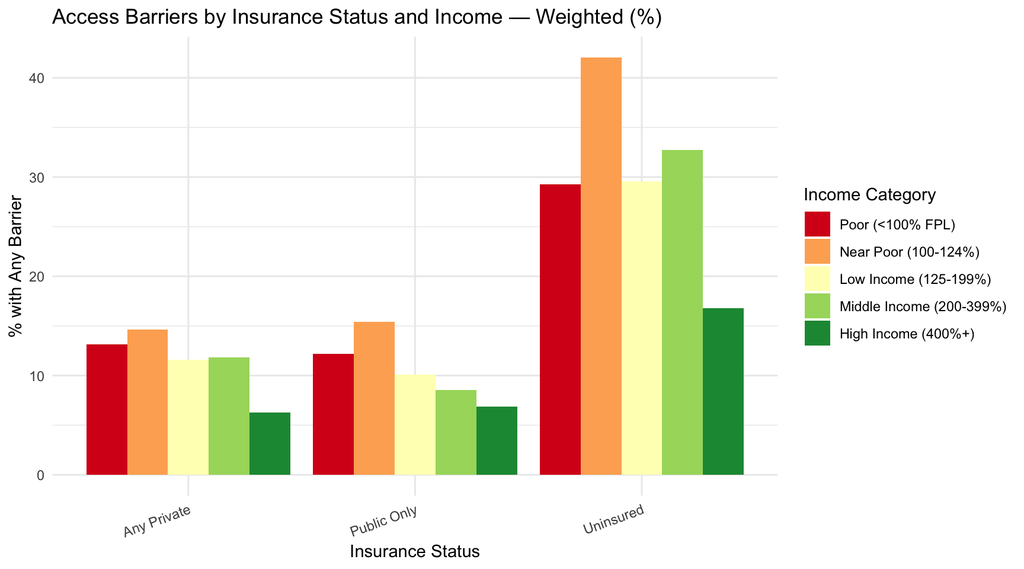

```r
barrier_ins_pov <- svyby(~any_barrier, ~ins_status + povcat,
                          meps_svy, svymean, na.rm = TRUE) %>%
  as.data.frame() %>%
  mutate(pct = any_barrier * 100)

ggplot(barrier_ins_pov, aes(x = ins_status, y = pct, fill = povcat)) +
  geom_col(position = "dodge") +
  scale_fill_brewer(palette = "RdYlGn", name = "Income Category") +
  labs(title = "Access Barriers by Insurance Status and Income — Weighted (%)",
       x = "Insurance Status", y = "% with Any Barrier") +
  theme_minimal() +
  theme(axis.text.x = element_text(angle = 20, hjust = 1))
```

```r
tb_pov_wtd <- prop.table(svytable(~povcat + any_barrier, meps_svy), 1)

rr_poor_hi <- tb_pov_wtd["Poor (<100% FPL)",      "1"] / tb_pov_wtd["High Income (400%+)", "1"]
rr_near_hi <- tb_pov_wtd["Near Poor (100-124%)",  "1"] / tb_pov_wtd["High Income (400%+)", "1"]
rr_low_hi  <- tb_pov_wtd["Low Income (125-199%)", "1"] / tb_pov_wtd["High Income (400%+)", "1"]
rr_middle_hi  <- tb_pov_wtd["Middle Income (200-399%)", "1"] / tb_pov_wtd["High Income (400%+)", "1"]

income_rr_tbl <- tibble(
  `Income Group`          = c("Poor (<100% FPL)", "Near Poor (100-124%)", "Low Income (125-199%)", "Middle Income (200-399%)"),
  `vs High Income (400%+)` = c(round(rr_poor_hi, 2), round(rr_near_hi, 2), round(rr_low_hi, 2), round(rr_middle_hi,2))
) %>% rename(`Risk Ratio` = `vs High Income (400%+)`)

knitr::kable(income_rr_tbl,
             caption = "Weighted Risk Ratios for Any Access Barrier vs High Income Adults") %>%
  kable_styling(bootstrap_options = c("striped", "hover"), full_width = FALSE)
```

Weighted Risk Ratios for Any Access Barrier vs High Income Adults

| Income Group | Risk Ratio |
| --- | --- |
| Poor (<100% FPL) | 2.24 |
| Near Poor (100-124%) | 2.79 |
| Low Income (125-199%) | 2.00 |
| Middle Income (200-399%) | 1.94 |

The income gradient in access barriers is also substantial in absolute terms. Poor adults are 2.2 times more likely to face a care barrier than high-income adults. Near-poor adults show an even higher relative risk of 2.8, reinforcing the near-poor trap hypothesis. Even low-income adults face a risk 2 times that of their high-income counterparts.

## Healthcare Utilization by Insurance Status

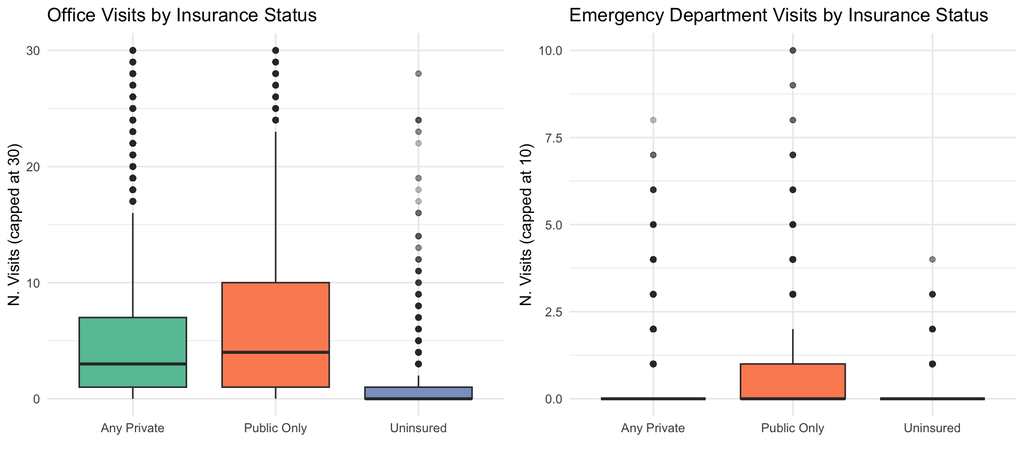

```r
p_ov <- meps_adults %>%
  filter(office_visits <= 30) %>%
  ggplot(aes(x = ins_status, y = office_visits, fill = ins_status)) +
  geom_boxplot(outlier.alpha = 0.3) +
  scale_fill_brewer(palette = "Set2") +
  labs(title = "Office Visits by Insurance Status",
       x = "", y = "N. Visits (capped at 30)") +
  theme_minimal() + theme(legend.position = "none")

p_er <- meps_adults %>%
  filter(er_visits <= 10) %>%
  ggplot(aes(x = ins_status, y = er_visits, fill = ins_status)) +
  geom_boxplot(outlier.alpha = 0.3) +
  scale_fill_brewer(palette = "Set2") +
  labs(title = "Emergency Department Visits by Insurance Status",
       x = "", y = "N. Visits (capped at 10)") +
  theme_minimal() + theme(legend.position = "none")

grid.arrange(p_ov, p_er, ncol = 2)
```

The utilization patterns by insurance status reveal two contrasting dynamics.Patients who have only public health insurance are the primary users of both healthcare services (outpatient clinics and emergency rooms).Otherwise, People with private insurance tend to visit offices more often, reflecting a solid engagement with outpatient care, but they make only very limited use of the emergency room.

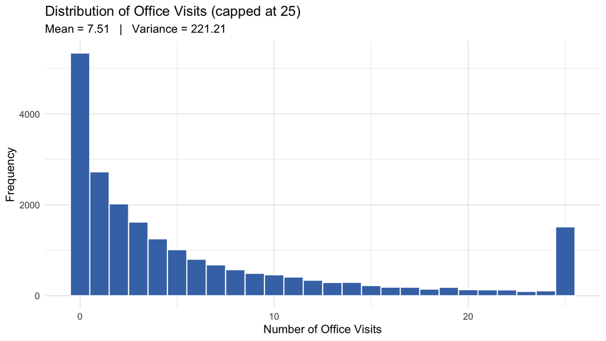

```r
ggplot(meps_adults, aes(x = pmin(office_visits, 25))) +
  geom_histogram(binwidth = 1, fill = "#4575B4", color = "white") +
  labs(title = "Distribution of Office Visits (capped at 25)",
       subtitle = paste0("Mean = ",
                          round(mean(meps_adults$office_visits, na.rm=TRUE), 2),
                          "   |   Variance = ",
                          round(var(meps_adults$office_visits, na.rm=TRUE), 2)),
       x = "Number of Office Visits", y = "Frequency") +
  theme_minimal()
```

The distribution of office visits is strongly right-skewed with a large mass at zero, a mean of 7.51 visits and a variance of 221.21. The variance far exceeds the mean, a direct indication of overdispersion that rules out the Poisson model and motivates the use of Negative Binomial regression, as we’ll see later.

## Out-of-Pocket Expenditure

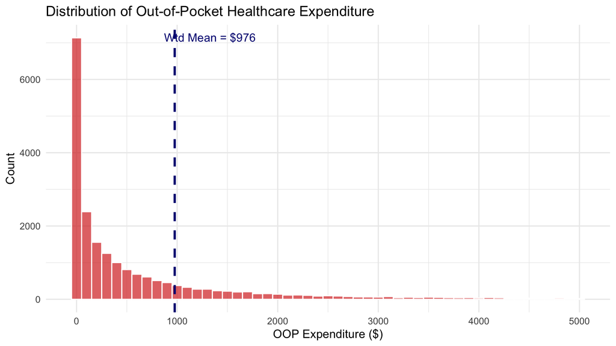

```r
wtd_oop <- svymean(~oop_exp, meps_svy, na.rm = TRUE)

ggplot(meps_adults %>% filter(oop_exp <= 5000), aes(x = oop_exp)) +
  geom_histogram(binwidth = 100, fill = "#d73027", color = "white", alpha = 0.7) +
  geom_vline(xintercept = as.numeric(wtd_oop),
             color = "navy", linetype = "dashed", size = 1) +
  annotate("text", x = as.numeric(wtd_oop) + 350, y = Inf,
           label = paste0("Wtd Mean = $", round(as.numeric(wtd_oop), 0)),
           vjust = 2, color = "navy", size = 3.8) +
  labs(title = "Distribution of Out-of-Pocket Healthcare Expenditure",
       x = "OOP Expenditure ($)", y = "Count") +
  theme_minimal()
```

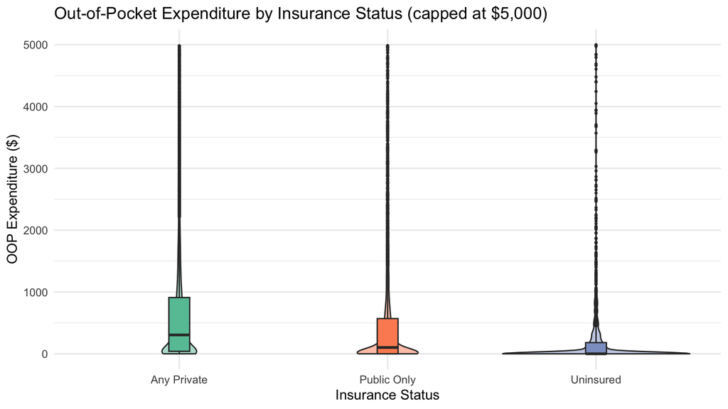

```r
meps_adults %>%
  filter(oop_exp <= 5000) %>%
  ggplot(aes(x = ins_status, y = oop_exp, fill = ins_status)) +
  geom_violin(alpha = 0.5, trim = TRUE) +
  geom_boxplot(width = 0.1, outlier.size = 0.5) +
  scale_fill_brewer(palette = "Set2") +
  labs(title = "Out-of-Pocket Expenditure by Insurance Status (capped at $5,000)",
       x = "Insurance Status", y = "OOP Expenditure ($)") +
  theme_minimal() + theme(legend.position = "none")
```

Out-of-pocket expenditure is strongly right-skewed, with a weighted population mean of approximately $976 and a long upper tail driven by a minority of high-cost cases. This plots by insurance status reveal an important pattern: privately insured adults concentrate the highest OOP expenditure,a notable proportion of uninsured adults report zero OOP expenditure.

*Why do people without insurance spend less?*

If we combine these graphs with the previous tables on barriers to access, we get the full picture: The uninsured do not spend less because they are healthier or because their care is free. They spend less because they forgo treatment.

As we saw earlier, 25.8% of them delay treatment and 18.1% cannot afford it. Consequently, since they cannot access the healthcare system, their actual out-of-pocket spending remains at zero. Those with private insurance encounter very few barriers (8.7%), and therefore end up paying out-of-pocket for costs more often.

## Geographic Distribution of Access Barriers

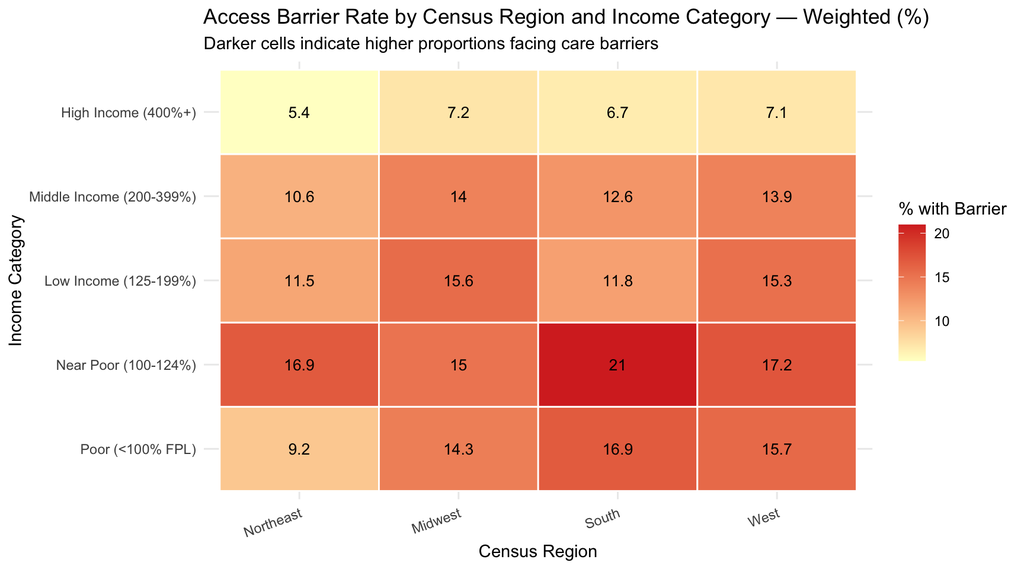

```r
region_barrier_pov <- svyby(~any_barrier, ~region + povcat,
                              meps_svy, svymean, na.rm = TRUE) %>%
  as.data.frame() %>%
  mutate(pct_barrier = any_barrier * 100)

ggplot(region_barrier_pov, aes(x = region, y = povcat, fill = pct_barrier)) +
  geom_tile(color = "white", size = 0.5) +
  geom_text(aes(label = round(pct_barrier, 1)), size = 3.5, color = "black") +
  scale_fill_gradient(low = "#ffffcc", high = "#d73027", name = "% with Barrier") +
  labs(title = "Access Barrier Rate by Census Region and Income Category — Weighted (%)",
       subtitle = "Darker cells indicate higher proportions facing care barriers",
       x = "Census Region", y = "Income Category") +
  theme_minimal() +
  theme(axis.text.x = element_text(angle = 20, hjust = 1))
```

```r
region_tbl <- svyby(
  ~any_barrier + uninsured + poor_health + office_visits,
  ~region, meps_svy, svymean, na.rm = TRUE
) %>%
  as.data.frame() %>%
  mutate(
    `% Any Barrier` = round(any_barrier   * 100, 1),
    `% Uninsured`   = round(uninsured     * 100, 1),
    `% Poor Health` = round(poor_health   * 100, 1),
    `Avg Visits`    = round(office_visits, 1)
  ) %>%
  dplyr::select(region, `% Any Barrier`, `% Uninsured`, `% Poor Health`, `Avg Visits`)

knitr::kable(region_tbl,
             caption = "Key Access and Health Indicators by Census Region — Weighted (%)") %>%
  kable_styling(bootstrap_options = c("striped", "hover"))
```

Key Access and Health Indicators by Census Region — Weighted (%)

|  | region | % Any Barrier | % Uninsured | % Poor Health | Avg Visits |
| --- | --- | --- | --- | --- | --- |
| Northeast | Northeast | 8.1 | 4.1 | 12.3 | 8.3 |
| Midwest | Midwest | 11.1 | 5.0 | 12.2 | 7.7 |
| South | South | 10.9 | 10.9 | 12.3 | 6.7 |
| West | West | 11.3 | 6.4 | 11.1 | 7.2 |

The geographic distribution of access barriers shows moderate variation across the four Census regions. The South consistently shows higher barrier and uninsured rates compared to the Northeast, while the West displays a mixed profile with above-average barrier rates in lower-income categories. The heatmap reveals that the income gradient in barriers is present in all regions.

Generally speaking, as we move down the income brackets (from top to bottom), the barriers increase significantly:

High Income: This group has the lowest barrier rates of all across all regions, ranging from 5.4% (Northeast) to 7.2% (Midwest).

Near Poor: Those in the “Near Poor” bracket face the worst situation. This is where the chart’s all-time high is recorded: 21% in the South.

Poor: Barriers decrease slightly compared to the Near Poor (for example, they drop to 9.2% in the Northeast).

Why is this happening?

Most likely because those below the absolute poverty line are eligible for comprehensive public assistance programs (such as Medicaid), while those who are “near poor” earn too much for public aid but too little to afford private care

## Correlation Among Key Continuous Variables

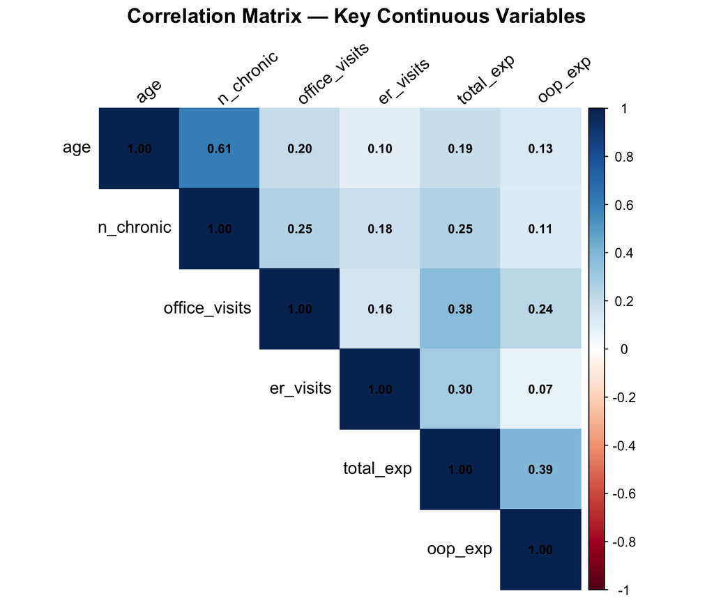

```r
num_df <- meps_adults %>%
  dplyr::select(age, n_chronic, office_visits, er_visits, total_exp, oop_exp) %>%
  na.omit()

corrplot(cor(num_df),
         method = "color", type = "upper",
         addCoef.col = "black", number.cex = 0.75,
         tl.col = "black", tl.srt = 40,
         title = "Correlation Matrix — Key Continuous Variables",
         mar = c(0, 0, 1.5, 0))
```

This correlationn matrix helps determine whether, as one health or demographic variable changes, another changes accordingly and in which direction.

Here is an analysis of the most significant relationships emerging from the matrix:

1. The strongest relationship: age and chronic diseases (0.61): this is the highest correlation, confirming an obvious yet crucial biological fact: population aging is strongly linked to the accumulation of chronic diseases.
2. The economic impact: Total Expenditure vs. Out-of-Pocket Expenditure (0.39) The correlation between total_exp and oop_exp is 0.39: there is a moderate correlation; if an individual’s total healthcare expenditure rises, the portion they must pay out of pocket also tends to rise.
3. Use of services: office visits vs. total expenditure (0.38): The variable office_visits (doctor’s office visits) correlates at 0.38 with total_exp. This tells us that the volume of routine office visits is one of the main drivers pushing up a patient’s overall healthcare costs (total_exp), much more so than emergency room visits (er_visits vs. total_exp stands at 0.30).
4. The weak link: chronic diseases and out-of-pocket expenses (0.11). An interesting finding is the very low correlation (0.11) between n_chronic and oop_exp. Although having more chronic diseases leads to more office visits (0.25) and increases total spending (0.25), the impact on the citizen’s out-of-pocket expenses (oop_exp) remains minimal.

# Logistic Regression

This part shifts the focus from descriptive analysis to causal inference. While the EDA demonstrated that access barriers exist and vary across demographic groups, the next step is a more precise investigation aimed at identifying the independent predictors of access barriers after controlling for age, sex, health status, education, and other potential confounders. The key objective is to determine whether insurance status persists as a significant driver of healthcare access disparities and which demographic groups face the highest barrier risk once cofactors are accounted for.

The outcome variable is “any_barrier”: a binary indicator equal to 1 if a respondent experienced either delayed care or unaffordable care in the past 12 months, and 0 otherwise. This outcome is well-suited to logistic regression, where the fitted model estimates the probability P(barrier = 1 | predictors) — the probability of facing at least one access barrier given observed characteristics.

## Bivariate Analysis

Before fitting the model, the relationship between the two main structural determinants of interest (insurance coverage and income level) and access barriers is examined. This preliminary analysis provides an initial assessment of the unadjusted association between socio-economic disadvantage and healthcare accessibility.

**Insurance Status and Barriers:**

```r
tb_ins <- prop.table(xtabs(~ ins_status + any_barrier, data = meps_adults), 1)
print(round(tb_ins, 3))
```

```
##              any_barrier
## ins_status        0     1
##   Any Private 0.912 0.088
##   Public Only 0.900 0.100
##   Uninsured   0.709 0.291
```

```r
rr_unins <- tb_ins["Uninsured", "1"] / tb_ins["Any Private", "1"]
or_unins <- (tb_ins["Uninsured", "1"] / tb_ins["Uninsured", "0"]) /
  (tb_ins["Any Private", "1"] / tb_ins["Any Private", "0"])
```

```
## Crude Risk Ratio (Uninsured vs Private): 3.31
```

```
## Crude Odds Ratio (Uninsured vs Private): 4.26
```

Approximately 29.2% of uninsured adults report access barriers, compared to just 8.8% of those with private insurance and 10.0% of those with public coverage. This translates to a crude risk ratio (RR) of 3.31: the uninsured are more than three times as likely to face barriers.

**Income and Barriers:**

```r
tb_pov <- prop.table(xtabs(~ povcat + any_barrier, data = meps_adults), 1)
print(round(tb_pov, 3))
```

```
##                           any_barrier
## povcat                         0     1
##   Poor (<100% FPL)         0.851 0.149
##   Near Poor (100-124%)     0.829 0.171
##   Low Income (125-199%)    0.861 0.139
##   Middle Income (200-399%) 0.876 0.124
##   High Income (400%+)      0.935 0.065
```

The income gradient reveals a coverage gap pattern: while high-income adults face the lowest barriers (6.5%), the poorest adults face barriers at 14.8%. In particular, near-poor individuals (17%) experience the highest barrier rate, a surprising finding consistent with the coverage gap hypothesis, where individuals just above the poverty threshold lose public insurance eligibility without gaining private coverage. This non-monotone gradient demonstrates that income matters substantially, but the discontinuity in insurance coverage at the poverty line creates the steepest disparities in barrier risk.

**Chi-square Test:**

```r
test_ins <- chisq.test(table(meps_adults$ins_status, meps_adults$any_barrier))
```

```
## Chi-square test (insurance × barrier):
```

```
## χ² = 692.8 , p-value = 3.634462e-151
```

```r
test_pov <- chisq.test(table(meps_adults$povcat, meps_adults$any_barrier))
```

```
## Chi-square test (income × barrier):
```

```
## χ² = 296.07 , p-value = 7.638966e-63
```

Both associations are highly significant (p < 0.001), confirming that insurance and income are not independent of access barriers. However, insurance and income are themselves associated: lower-income individuals are more likely to be uninsured or publicly insured. When we fit the multivariable model below, we expect the crude OR to shrink after we control for income, but if the adjusted OR remains substantially high, this indicates that insurance effects are not merely a proxy for income.

```r
# Set reference levels for categorical variables
meps_adults$ins_status <- relevel(meps_adults$ins_status, ref = "Any Private")
meps_adults$povcat <- relevel(meps_adults$povcat, ref = "High Income (400%+)")
meps_adults$race_eth <- relevel(meps_adults$race_eth, ref = "White Non-Hispanic")
meps_adults$sex <- relevel(meps_adults$sex, ref = "Male")
meps_adults$age_group <- relevel(meps_adults$age_group, ref = "18-34")
```

**Reference Categories Chosen:**

- **Insurance**: “Any Private”
- **Income**: “High Income (400%+ FPL)”
- **Race/Ethnicity**: “White Non-Hispanic”
- **Sex**: “Male”
- **Age**: “18-34”

## Test: Are Survey Weights Necessary?

The MEPS survey design involves sampling weights (`perwt`), strata (`varstr`), and clusters (`varpsu`). Ideally, regression models would incorporate this design information to produce valid population-level inference. However, standard GLM functions in R do not support complex survey designs. To determine whether ignoring weights causes bias, we test whether normalized weights are significant predictors in an unweighted logistic model.

```r
# Include normalized weights as a fixed effect to test their significance
model_weights_test <- glm(any_barrier ~ ins_status + povcat + sex + age_group + race_eth +
                          poor_health + any_chronic + educ_cat + region + perwt_norm,
                          family = binomial,
                          data = meps_adults)

weights_coef <- coef(model_weights_test)["perwt_norm"]
weights_se <- summary(model_weights_test)$coefficients["perwt_norm", "Std. Error"]
weights_z <- summary(model_weights_test)$coefficients["perwt_norm", "z value"]
weights_p <- summary(model_weights_test)$coefficients["perwt_norm", "Pr(>|z|)"]
```

```
## Coefficient: 0.041186
```

```
## Std. Error: 0.038136
```

```
## z-statistic: 1.08
```

```
## p-value: 0.2802
```

The weights are not statistically significant (p > 0.05), indicating that the unweighted logistic model produces population-representative estimates.

## Logistic Regression Model

```r
model_logit <- glm(any_barrier ~ ins_status + povcat + sex + age_group + race_eth +
                   poor_health + any_chronic + educ_cat + region,
                   family = binomial,
                   data = meps_adults)

summary(model_logit)
```

```
##
## Call:
## glm(formula = any_barrier ~ ins_status + povcat + sex + age_group +
##     race_eth + poor_health + any_chronic + educ_cat + region,
##     family = binomial, data = meps_adults)
##
## Coefficients:
##                                Estimate Std. Error z value Pr(>|z|)
## (Intercept)                    -3.30150    0.14220 -23.217  < 2e-16 ***
## ins_statusPublic Only          -0.02528    0.06374  -0.397 0.691652
## ins_statusUninsured             1.36369    0.06977  19.545  < 2e-16 ***
## povcatPoor (<100% FPL)          0.69704    0.08286   8.412  < 2e-16 ***
## povcatNear Poor (100-124%)      1.05455    0.10850   9.719  < 2e-16 ***
## povcatLow Income (125-199%)     0.76634    0.07837   9.778  < 2e-16 ***
## povcatMiddle Income (200-399%)  0.66375    0.06351  10.451  < 2e-16 ***
## sexFemale                       0.31538    0.04706   6.702 2.05e-11 ***
## age_group35-49                 -0.05746    0.06405  -0.897 0.369627
## age_group50-64                 -0.06567    0.06965  -0.943 0.345792
## age_group65+                   -1.06535    0.08880 -11.997  < 2e-16 ***
## race_ethBlack Non-Hispanic     -0.30890    0.07305  -4.228 2.35e-05 ***
## race_ethHispanic               -0.29696    0.06360  -4.669 3.02e-06 ***
## race_ethAsian Non-Hispanic     -0.77381    0.37923  -2.041 0.041300 *
## race_ethOther/Mixed            -0.31243    0.09425  -3.315 0.000917 ***
## poor_health                     0.78490    0.05990  13.104  < 2e-16 ***
## any_chronic                     0.37324    0.05774   6.464 1.02e-10 ***
## educ_catSome HS                 0.03983    0.11491   0.347 0.728852
## educ_catHS Grad                 0.05563    0.10408   0.534 0.593032
## educ_catSome College            0.27298    0.10791   2.530 0.011413 *
## educ_catCollege+                0.30501    0.11140   2.738 0.006184 **
## regionMidwest                   0.25002    0.08143   3.071 0.002136 **
## regionSouth                     0.15866    0.07596   2.089 0.036728 *
## regionWest                      0.33959    0.07902   4.298 1.73e-05 ***
## ---
## Signif. codes:  0 '***' 0.001 '**' 0.01 '*' 0.05 '.' 0.1 ' ' 1
##
## (Dispersion parameter for binomial family taken to be 1)
##
##     Null deviance: 14604  on 21217  degrees of freedom
## Residual deviance: 13352  on 21194  degrees of freedom
##   (149 observations deleted due to missingness)
## AIC: 13400
##
## Number of Fisher Scoring iterations: 5
```

## Odds Ratios

```r
# Extract adjusted odds ratios with 95% CIs
logit_tidy <- broom::tidy(model_logit, exponentiate = TRUE, conf.int = TRUE) %>%
  filter(term != "(Intercept)") %>%
  rename(OR = estimate, CI_low = conf.low, CI_high = conf.high) %>%
  mutate(Significant = ifelse(p.value < 0.05, "Yes", "No"))

knitr::kable(
  logit_tidy %>% dplyr::select(term, OR, CI_low, CI_high, p.value, Significant),
  digits = 3,
  caption = "Logistic Regression: Adjusted Odds Ratios for Any Access Barrier"
) %>%
  kable_styling(bootstrap_options = c("striped", "hover"))
```

Logistic Regression: Adjusted Odds Ratios for Any Access Barrier

| term | OR | CI_low | CI_high | p.value | Significant |
| --- | --- | --- | --- | --- | --- |
| ins_statusPublic Only | 0.975 | 0.860 | 1.104 | 0.692 | No |
| ins_statusUninsured | 3.911 | 3.410 | 4.483 | 0.000 | Yes |
| povcatPoor (<100% FPL) | 2.008 | 1.706 | 2.361 | 0.000 | Yes |
| povcatNear Poor (100-124%) | 2.871 | 2.316 | 3.545 | 0.000 | Yes |
| povcatLow Income (125-199%) | 2.152 | 1.845 | 2.509 | 0.000 | Yes |
| povcatMiddle Income (200-399%) | 1.942 | 1.715 | 2.200 | 0.000 | Yes |
| sexFemale | 1.371 | 1.250 | 1.504 | 0.000 | Yes |
| age_group35-49 | 0.944 | 0.833 | 1.070 | 0.370 | No |
| age_group50-64 | 0.936 | 0.817 | 1.073 | 0.346 | No |
| age_group65+ | 0.345 | 0.289 | 0.410 | 0.000 | Yes |
| race_ethBlack Non-Hispanic | 0.734 | 0.635 | 0.846 | 0.000 | Yes |
| race_ethHispanic | 0.743 | 0.656 | 0.841 | 0.000 | Yes |
| race_ethAsian Non-Hispanic | 0.461 | 0.202 | 0.912 | 0.041 | Yes |
| race_ethOther/Mixed | 0.732 | 0.606 | 0.877 | 0.001 | Yes |
| poor_health | 2.192 | 1.949 | 2.464 | 0.000 | Yes |
| any_chronic | 1.452 | 1.297 | 1.627 | 0.000 | Yes |
| educ_catSome HS | 1.041 | 0.832 | 1.306 | 0.729 | No |
| educ_catHS Grad | 1.057 | 0.864 | 1.300 | 0.593 | No |
| educ_catSome College | 1.314 | 1.066 | 1.627 | 0.011 | Yes |
| educ_catCollege+ | 1.357 | 1.093 | 1.692 | 0.006 | Yes |
| regionMidwest | 1.284 | 1.096 | 1.508 | 0.002 | Yes |
| regionSouth | 1.172 | 1.011 | 1.362 | 0.037 | Yes |
| regionWest | 1.404 | 1.204 | 1.642 | 0.000 | Yes |

## Model Fit and Predictive Accuracy

```r
# Null model (intercept only)
null_logit <- glm(any_barrier ~ 1, family = binomial, data = meps_adults)
```

```r
# McFadden's Pseudo-R²
pseudo_r2 <- 1 - logLik(model_logit) / logLik(null_logit)
```

```
## McFadden's Pseudo-R²: 0.091
```

```r
# ROC curve and AUC
predicted_probs <- predict(model_logit, type = "response")
roc_obj <- roc(model_logit$y, predicted_probs)
auc_value <- auc(roc_obj)
```

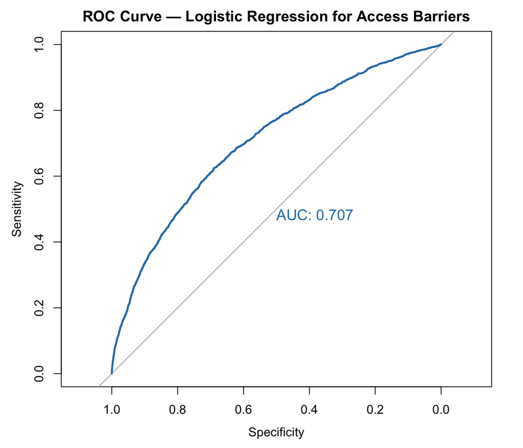

```r
plot(roc_obj, col = "#2C7BB6", lwd = 2.5,
     main = "ROC Curve — Logistic Regression for Access Barriers",
     cex.main = 1.2, print.auc = TRUE,
     print.auc.x = 0.5, print.auc.cex = 1.2)
```

The model achieves an AUC of 0.707, indicating good discrimination: the model correctly ranks a random barrier case as higher risk than a random non-barrier case about 70% of the time.

## Predicted Probabilities

To make the model results interpretable, we compute predicted barrier probabilities across insurance status and income levels, holding all other variables at their modal or mean values.

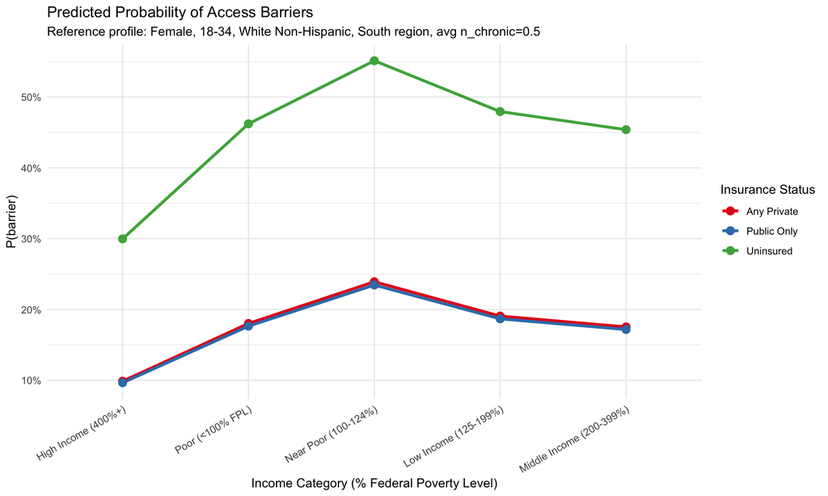

```r
avg_values <- list(sex = names(sort(table(meps_adults$sex), decreasing = TRUE))[1],
                   age_group = names(sort(table(meps_adults$age_group), decreasing = TRUE))[1],
                   race_eth = names(sort(table(meps_adults$race_eth), decreasing = TRUE))[1],
                   educ_cat = names(sort(table(meps_adults$educ_cat), decreasing = TRUE))[1],
                   region = names(sort(table(meps_adults$region), decreasing = TRUE))[1],
                   poor_health = mean(meps_adults$poor_health, na.rm = TRUE),
                   any_chronic = mean(meps_adults$any_chronic, na.rm = TRUE))

pred_grid <- expand.grid(ins_status = levels(meps_adults$ins_status),
                         povcat = levels(meps_adults$povcat),
                         sex = avg_values$sex,
                         age_group = avg_values$age_group,
                         race_eth = avg_values$race_eth,
                         educ_cat = avg_values$educ_cat,
                         region = avg_values$region,
                         poor_health = avg_values$poor_health,
                         any_chronic = avg_values$any_chronic)

pred_grid$prob <- predict(model_logit, newdata = pred_grid, type = "response")

subtitle_text <- sprintf("Reference profile: %s, %s, %s, %s region, avg n_chronic=%.1f",
                         avg_values$sex, avg_values$age_group, avg_values$race_eth,
                         avg_values$region, avg_values$any_chronic)

ggplot(pred_grid, aes(x = povcat, y = prob, color = ins_status, group = ins_status)) +
       geom_line(size = 1.2) +
       geom_point(size = 3) +
       scale_color_brewer(palette = "Set1", name = "Insurance Status") +
       scale_y_continuous(labels = percent_format()) +
       labs(title = "Predicted Probability of Access Barriers",
            subtitle = subtitle_text,
            x = "Income Category (% Federal Poverty Level)",
            y = "P(barrier)") +
       theme_minimal() +
       theme(axis.text.x = element_text(angle = 30, hjust = 1, size = 9))
```

The graph illustrates how insurance status and income jointly shape predicted access barriers:

- **Insurance effect**: Across all income categories, uninsured individuals exhibit substantially higher predicted barrier probabilities than both privately and publicly insured individuals, highlighting the central role of insurance coverage in healthcare access.
- **Income gradient**: Within each insurance group, barrier probabilities generally increase as income decreases, indicating that economic disadvantage amplifies difficulties in accessing care.
- **Concentrated vulnerability**: The highest predicted barrier probabilities are observed among uninsured near-poor individuals, whose risk exceeds 50%, while high-income insured individuals experience the lowest probabilities of barriers.
- **Public coverage as partial protection**: After adjustment, publicly insured individuals display barrier probabilities that are very similar to (and in some cases slightly lower than) privately insured individuals, suggesting that public insurance may partially offset the disadvantages associated with low income.

The model supports the hypothesis that healthcare access in the United States is jointly shaped by insurance coverage and socioeconomic status, producing substantial disparities in the ability to obtain healthcare.

# Negative Binomial Regression

This part of the analysis answers the following question: who uses more healthcare services, and what drives those differences?

The two outcomes studied are office-based visits (office_visits) and emergency room visits (er_visits), both nonnegative count variables that measure how many times each patient accessed a specific type of care in USA, during 2019.

So, which statistical model is appropriate for count data like these? The natural candidate is the Poisson model, which is designed for nonnegative count data. However, Poisson carries a strict assumption, i.e the variance must equal the mean. But in this scenario we’ll see how a small fraction of patients accumulate a disproportionately large share of visits, creating a heavily right-skewed distribution where variance far exceeds the mean. This condition is called overdispersion, and fitting a Poisson model to overdispersed data produces incorrect inference.

The Negative Binomial (NB) model solves this problem, by adding a dispersion parameter θ (theta) such that the variance can exceed the mean.

**Test for Overdispersion**

The purpose of the first chunk if test whether Poisson is adequate. The first block estimates a baseline Poisson model and then performs the test for overdispersion using AER::dispersiontest(). This test formally verifies whether the variance of the data significantly exceeds the mean.

We consider Var(Y) = μ + αf(μ)

The parameter α (alpha) represents a diagnostic tool, and we assume that if:

H0 : α = 0, so variance euqals to mean,we are in the Poisson case; H1 : α ≠ 0, the Negative Binomial model is preferable.

Why it matters?

• A Poisson model with overdispersion produces underestimated standard errors

• This inflates z-scores and lowers p-values

• There is a risk of declaring predictors significant that are not (false positive)

• The NB model corrects this problem by adding a dispersion parameter θ (theta)

```r
pois_model_office  <- glm(
  office_visits ~ ins_status + age_group + sex + race_eth + povcat + n_chronic + poor_health + educ_cat + region + any_barrier,
  family = poisson,
  data   = meps_adults
)

pois_model_er <- glm(
  er_visits ~ ins_status + age_group + sex + race_eth + povcat +
    n_chronic + poor_health + educ_cat + any_barrier + region,
  family = poisson,
  data = meps_adults
)

disp_test1 <- AER::dispersiontest(pois_model_office, trafo = 1)
disp_test2 <- AER::dispersiontest(pois_model_er, trafo = 1)
print(disp_test1)
```

```
##
##  Overdispersion test
##
## data:  pois_model_office
## z = 7.2042, p-value = 2.919e-13
## alternative hypothesis: true alpha is greater than 0
## sample estimates:
##    alpha
## 25.00276
```

```r
print(disp_test2)
```

```
##
##  Overdispersion test
##
## data:  pois_model_er
## z = 9.73, p-value < 2.2e-16
## alternative hypothesis: true alpha is greater than 0
## sample estimates:
##     alpha
## 0.6393047
```

```r
cat("α (dispersion):", round(disp_test1$estimate, 3), "\n")
```

```
## α (dispersion): 25.003
```

```r
cat("α (dispersion):", round(disp_test2$estimate, 3), "\n")
```

```
## α (dispersion): 0.639
```

```r
cat("AIC:", round(AIC(pois_model_office), 1), "\n")
```

```
## AIC: 298227.7
```

```r
cat("AIC:", round(AIC(pois_model_er), 1), "\n")
```

```
## AIC: 25555.6
```

POISSON MODEL ER VISITS: α = 0.639, z = 9.73, p-value < 2.2e-16 There is also significant overdispersion for the ER, although to a lesser extent (the distribution is more concentrated around zero with a long right tail).

A small fraction of patients accounts for a disproportionately high number of visits, resulting in a distribution that is heavily skewed to the right, where the variance far exceeds the mean.

The code also prints AIC for both Poisson models. These values serve as the baseline for comparison in the fit summary table.

So, A Poisson model applied to these data would have underestimated the standard errors, inflated the z-scores, and produced systematic false positives.

## Negative Binomial Models

To correct for this, we implemented Negative Binomial (NB) models via maximum likelihood (MASS::glm.nb)

Both models are based on the same 10 predictors, covering all major dimensions of healthcare.

Theta θ is the dispersion parameter that describes data distribution and controls the dispersion.

We refer to Var[Y] = μ + μ²/θ

Since θ appears in the denominator of the variance, a small θ indicates high overdispersion;

when θ is high (θ → ∞), the variance converges to μ and the model converges to the Poisson distribution.

```r
model_nb_office <- MASS::glm.nb(
  office_visits ~ ins_status + age_group + sex + race_eth + povcat +
    n_chronic + poor_health + educ_cat + any_barrier + region,
  data = meps_adults
)

summary(model_nb_office)
```

```
##
## Call:
## MASS::glm.nb(formula = office_visits ~ ins_status + age_group +
##     sex + race_eth + povcat + n_chronic + poor_health + educ_cat +
##     any_barrier + region, data = meps_adults, init.theta = 0.6126571469,
##     link = log)
##
## Coefficients:
##                                 Estimate Std. Error z value Pr(>|z|)
## (Intercept)                     1.300926   0.057981  22.437  < 2e-16 ***
## ins_statusPublic Only           0.109123   0.024991   4.367 1.26e-05 ***
## ins_statusUninsured            -1.164258   0.042255 -27.553  < 2e-16 ***
## age_group35-49                  0.161439   0.027882   5.790 7.03e-09 ***
## age_group50-64                  0.186463   0.029372   6.348 2.18e-10 ***
## age_group65+                    0.377158   0.033561  11.238  < 2e-16 ***
## sexFemale                       0.384913   0.018971  20.290  < 2e-16 ***
## race_ethBlack Non-Hispanic     -0.427487   0.029676 -14.405  < 2e-16 ***
## race_ethHispanic               -0.407962   0.027409 -14.884  < 2e-16 ***
## race_ethAsian Non-Hispanic     -0.147978   0.130977  -1.130 0.258560
## race_ethOther/Mixed            -0.373083   0.036286 -10.282  < 2e-16 ***
## povcatPoor (<100% FPL)         -0.086196   0.034402  -2.506 0.012227 *
## povcatNear Poor (100-124%)     -0.234478   0.050494  -4.644 3.42e-06 ***
## povcatLow Income (125-199%)    -0.191989   0.032139  -5.974 2.32e-09 ***
## povcatMiddle Income (200-399%) -0.187027   0.024224  -7.721 1.16e-14 ***
## n_chronic                       0.270531   0.009379  28.843  < 2e-16 ***
## poor_health                     0.522915   0.028365  18.435  < 2e-16 ***
## educ_catSome HS                 0.020588   0.051574   0.399 0.689759
## educ_catHS Grad                 0.036232   0.046252   0.783 0.433416
## educ_catSome College            0.251118   0.047784   5.255 1.48e-07 ***
## educ_catCollege+                0.389849   0.048220   8.085 6.23e-16 ***
## any_barrier                     0.138979   0.031216   4.452 8.50e-06 ***
## regionMidwest                  -0.126509   0.030801  -4.107 4.00e-05 ***
## regionSouth                    -0.281714   0.028331  -9.944  < 2e-16 ***
## regionWest                     -0.104954   0.029971  -3.502 0.000462 ***
## ---
## Signif. codes:  0 '***' 0.001 '**' 0.01 '*' 0.05 '.' 0.1 ' ' 1
##
## (Dispersion parameter for Negative Binomial(0.6127) family taken to be 1)
##
##     Null deviance: 29459  on 21217  degrees of freedom
## Residual deviance: 23430  on 21193  degrees of freedom
##   (149 observations deleted due to missingness)
## AIC: 119822
##
## Number of Fisher Scoring iterations: 1
##
##
##               Theta:  0.61266
##           Std. Err.:  0.00693
##
##  2 x log-likelihood:  -119769.68700
```

```r
cat("\nNB Theta:", round(model_nb_office$theta, 3), "\n")
```

```
##
## NB Theta: 0.613
```

```r
cat("AIC:", round(AIC(model_nb_office), 1), "\n")
```

```
## AIC: 119821.7
```

```r
model_nb_er <- MASS::glm.nb(
  er_visits ~ ins_status + age_group + sex + race_eth + povcat +
    n_chronic + poor_health + educ_cat + any_barrier + region,
  data = meps_adults
)

summary(model_nb_er)
```

```
##
## Call:
## MASS::glm.nb(formula = er_visits ~ ins_status + age_group + sex +
##     race_eth + povcat + n_chronic + poor_health + educ_cat +
##     any_barrier + region, data = meps_adults, init.theta = 0.5020547263,
##     link = log)
##
## Coefficients:
##                                 Estimate Std. Error z value Pr(>|z|)
## (Intercept)                    -2.349966   0.110734 -21.222  < 2e-16 ***
## ins_statusPublic Only           0.327023   0.044876   7.287 3.16e-13 ***
## ins_statusUninsured            -0.393022   0.086167  -4.561 5.09e-06 ***
## age_group35-49                 -0.100402   0.057474  -1.747  0.08065 .
## age_group50-64                 -0.161466   0.059580  -2.710  0.00673 **
## age_group65+                   -0.007248   0.064273  -0.113  0.91022
## sexFemale                       0.226404   0.037010   6.117 9.51e-10 ***
## race_ethBlack Non-Hispanic      0.064769   0.052579   1.232  0.21801
## race_ethHispanic               -0.355141   0.055300  -6.422 1.34e-10 ***
## race_ethAsian Non-Hispanic      0.198805   0.213378   0.932  0.35149
## race_ethOther/Mixed            -0.341587   0.078589  -4.347 1.38e-05 ***
## povcatPoor (<100% FPL)          0.370239   0.062564   5.918 3.26e-09 ***
## povcatNear Poor (100-124%)      0.340033   0.087292   3.895 9.81e-05 ***
## povcatLow Income (125-199%)     0.238498   0.060911   3.915 9.02e-05 ***
## povcatMiddle Income (200-399%)  0.117152   0.049594   2.362  0.01817 *
## n_chronic                       0.204608   0.016908  12.101  < 2e-16 ***
## poor_health                     0.881608   0.044919  19.627  < 2e-16 ***
## educ_catSome HS                 0.383270   0.091313   4.197 2.70e-05 ***
## educ_catHS Grad                 0.209700   0.084471   2.483  0.01305 *
## educ_catSome College            0.197952   0.087934   2.251  0.02438 *
## educ_catCollege+               -0.055543   0.091136  -0.609  0.54223
## any_barrier                     0.284141   0.054883   5.177 2.25e-07 ***
## regionMidwest                   0.102329   0.058938   1.736  0.08253 .
## regionSouth                    -0.013509   0.054746  -0.247  0.80509
## regionWest                     -0.066543   0.059729  -1.114  0.26525
## ---
## Signif. codes:  0 '***' 0.001 '**' 0.01 '*' 0.05 '.' 0.1 ' ' 1
##
## (Dispersion parameter for Negative Binomial(0.5021) family taken to be 1)
##
##     Null deviance: 12667  on 21217  degrees of freedom
## Residual deviance: 10693  on 21193  degrees of freedom
##   (149 observations deleted due to missingness)
## AIC: 23737
##
## Number of Fisher Scoring iterations: 1
##
##
##               Theta:  0.5021
##           Std. Err.:  0.0221
##
##  2 x log-likelihood:  -23685.4060
```

```r
cat("\nNB Theta:", round(model_nb_er$theta, 3), "\n")
```

```
##
## NB Theta: 0.502
```

```r
cat("AIC:", round(AIC(model_nb_er), 1), "\n")
```

```
## AIC: 23737.4
```

In our case, θ = 0.613 (outpatient visits) and θ = 0.502 (ER), which confirm that the Negative Binomial model is the right choice.

**Model Comparison**

Likelihood Ratio Test — Poisson vs. NB The LRT formally tests whether adding θ improves the model significantly.

```r
cat("Poisson vs Negative Binomial (Office Visits and ER visits)")
```

```
## Poisson vs Negative Binomial (Office Visits and ER visits)
```

```r
lmtest::lrtest(pois_model_office, model_nb_office)
```

```
## Likelihood ratio test
##
## Model 1: office_visits ~ ins_status + age_group + sex + race_eth + povcat +
##     n_chronic + poor_health + educ_cat + region + any_barrier
## Model 2: office_visits ~ ins_status + age_group + sex + race_eth + povcat +
##     n_chronic + poor_health + educ_cat + any_barrier + region
##   #Df  LogLik Df  Chisq Pr(>Chisq)
## 1  25 -149089
## 2  26  -59885  1 178408  < 2.2e-16 ***
## ---
## Signif. codes:  0 '***' 0.001 '**' 0.01 '*' 0.05 '.' 0.1 ' ' 1
```

```r
lmtest::lrtest(pois_model_er, model_nb_er)
```

```
## Likelihood ratio test
##
## Model 1: er_visits ~ ins_status + age_group + sex + race_eth + povcat +
##     n_chronic + poor_health + educ_cat + any_barrier + region
## Model 2: er_visits ~ ins_status + age_group + sex + race_eth + povcat +
##     n_chronic + poor_health + educ_cat + any_barrier + region
##   #Df LogLik Df  Chisq Pr(>Chisq)
## 1  25 -12753
## 2  26 -11843  1 1820.2  < 2.2e-16 ***
## ---
## Signif. codes:  0 '***' 0.001 '**' 0.01 '*' 0.05 '.' 0.1 ' ' 1
```

So, going back to our original question: who does and who doesn’t have access?

The criterion for selecting the most relevant variables combines three elements: the magnitude of the IRR , statistical significance (high z-score,low p-value), and theoretical relevance with respect to the hidden exclusion hypotesis.

## IRR Results

```r
# Office visits
office_tidy <- broom::tidy(model_nb_office, exponentiate = TRUE, conf.int = TRUE) %>%
  filter(term != "(Intercept)") %>%
  rename(IRR = estimate, CI_low = conf.low, CI_high = conf.high)

knitr::kable(office_tidy %>% dplyr::select(term, IRR, CI_low, CI_high, p.value),
             digits = 3,
             caption = "NB Regression: Incidence Rate Ratios — Office Visits") %>%
  kable_styling(bootstrap_options = c("striped", "hover"))
```

NB Regression: Incidence Rate Ratios — Office Visits

| term | IRR | CI_low | CI_high | p.value |
| --- | --- | --- | --- | --- |
| ins_statusPublic Only | 1.115 | 1.063 | 1.171 | 0.000 |
| ins_statusUninsured | 0.312 | 0.288 | 0.339 | 0.000 |
| age_group35-49 | 1.175 | 1.113 | 1.241 | 0.000 |
| age_group50-64 | 1.205 | 1.138 | 1.276 | 0.000 |
| age_group65+ | 1.458 | 1.368 | 1.554 | 0.000 |
| sexFemale | 1.469 | 1.416 | 1.525 | 0.000 |
| race_ethBlack Non-Hispanic | 0.652 | 0.616 | 0.691 | 0.000 |
| race_ethHispanic | 0.665 | 0.631 | 0.701 | 0.000 |
| race_ethAsian Non-Hispanic | 0.862 | 0.673 | 1.125 | 0.259 |
| race_ethOther/Mixed | 0.689 | 0.642 | 0.740 | 0.000 |
| povcatPoor (<100% FPL) | 0.917 | 0.858 | 0.982 | 0.012 |
| povcatNear Poor (100-124%) | 0.791 | 0.718 | 0.873 | 0.000 |
| povcatLow Income (125-199%) | 0.825 | 0.775 | 0.879 | 0.000 |
| povcatMiddle Income (200-399%) | 0.829 | 0.791 | 0.870 | 0.000 |
| n_chronic | 1.311 | 1.287 | 1.335 | 0.000 |
| poor_health | 1.687 | 1.597 | 1.783 | 0.000 |
| educ_catSome HS | 1.021 | 0.922 | 1.129 | 0.690 |
| educ_catHS Grad | 1.037 | 0.947 | 1.134 | 0.433 |
| educ_catSome College | 1.285 | 1.171 | 1.410 | 0.000 |
| educ_catCollege+ | 1.477 | 1.344 | 1.621 | 0.000 |
| any_barrier | 1.149 | 1.081 | 1.223 | 0.000 |
| regionMidwest | 0.881 | 0.829 | 0.936 | 0.000 |
| regionSouth | 0.754 | 0.714 | 0.797 | 0.000 |
| regionWest | 0.900 | 0.849 | 0.955 | 0.000 |

```r
# ER visits - emergency room visits
er_tidy <- broom::tidy(model_nb_er, exponentiate = TRUE, conf.int = TRUE) %>%
  filter(term != "(Intercept)") %>%
  rename(IRR = estimate, CI_low = conf.low, CI_high = conf.high)

knitr::kable(
  er_tidy %>% dplyr::select(term, IRR, CI_low, CI_high, p.value),
  digits  = 3,
  caption = "NB Regression: Incidence Rate Ratios — ER Visits"
) %>%
  kable_styling(bootstrap_options = c("striped", "hover"))
```

NB Regression: Incidence Rate Ratios — ER Visits

| term | IRR | CI_low | CI_high | p.value |
| --- | --- | --- | --- | --- |
| ins_statusPublic Only | 1.387 | 1.271 | 1.513 | 0.000 |
| ins_statusUninsured | 0.675 | 0.569 | 0.798 | 0.000 |
| age_group35-49 | 0.904 | 0.809 | 1.012 | 0.081 |
| age_group50-64 | 0.851 | 0.757 | 0.956 | 0.007 |
| age_group65+ | 0.993 | 0.875 | 1.126 | 0.910 |
| sexFemale | 1.254 | 1.166 | 1.349 | 0.000 |
| race_ethBlack Non-Hispanic | 1.067 | 0.961 | 1.184 | 0.218 |
| race_ethHispanic | 0.701 | 0.629 | 0.781 | 0.000 |
| race_ethAsian Non-Hispanic | 1.220 | 0.796 | 1.862 | 0.351 |
| race_ethOther/Mixed | 0.711 | 0.610 | 0.826 | 0.000 |
| povcatPoor (<100% FPL) | 1.448 | 1.281 | 1.637 | 0.000 |
| povcatNear Poor (100-124%) | 1.405 | 1.183 | 1.667 | 0.000 |
| povcatLow Income (125-199%) | 1.269 | 1.127 | 1.429 | 0.000 |
| povcatMiddle Income (200-399%) | 1.124 | 1.020 | 1.239 | 0.018 |
| n_chronic | 1.227 | 1.187 | 1.268 | 0.000 |
| poor_health | 2.415 | 2.214 | 2.634 | 0.000 |
| educ_catSome HS | 1.467 | 1.224 | 1.760 | 0.000 |
| educ_catHS Grad | 1.233 | 1.044 | 1.459 | 0.013 |
| educ_catSome College | 1.219 | 1.025 | 1.451 | 0.024 |
| educ_catCollege+ | 0.946 | 0.791 | 1.132 | 0.542 |
| any_barrier | 1.329 | 1.192 | 1.481 | 0.000 |
| regionMidwest | 1.108 | 0.987 | 1.244 | 0.083 |
| regionSouth | 0.987 | 0.886 | 1.099 | 0.805 |
| regionWest | 0.936 | 0.833 | 1.052 | 0.265 |

**Office Visits. Who Accesses More?**

**n_chronic** (IRR = 1.311, z = 28.8, p < 2e-16) is the strongest predictor in the entire model. Each additional chronic condition increases visits by 31%. Actual clinical need translates into utilization.

**poor_health** (IRR = 1.687, z = 18.4, p < 2e-16), people who perceive their health as poor make 69% more visits. This is the second strongest clinical predictor and is highly significant.

**sexFemale** (IRR = 1.469, z = 20.3, p < 2e-16), Women account for 47% more visits than men.

**educ_catCollege+** ,so college-educated adults (IRR = 1.477, z = 8.1, p < 2e-16), college graduates account for 48% more visits than those who did not complete middle school. Reflecting greater ability to navigate the healthcare system.

**age_group65+**, adults over 65, (IRR = 1.458, z = 11.2, p < 2e-16), account for 46% more visits than those aged 18–34, benefit from Medicare coverage to access more easily in the system.

**ER Visits. Who Accesses More?**

**Poor_health** is again the dominant predictor but with a much larger effect (IRR = 2.415, z = 19.6, p < 2e-16). Those with poor perceived health are 2.4 times more likely to visit the ER. Note that the same predictor yielded an IRR of 1.687 for office visits: the effect is much greater for the ER, suggesting that those who arrive at the emergency room are already in a worse clinical condition, with accumulated needs that were not addressed earlier

**Poor adults** now show a positive coefficient, the complete reversal of their office visit. In particular:

**Office Visits. Who Accesses Less?**

**Non-Hispanic Black adults** (IRR = 0.652, |z| = 14.4, p < 2e-16) and **Hispanic adults** (IRR = 0.665, |z| = 14.9, p < 2e-16) both show deficits of roughly 35% relative to non-Hispanic White adults, after controlling for insurance, income, and health status.

**povcatNear Poor 100–124%** (IRR = 0.791, |z| = 4.6, p < 0.001), 21% fewer visits compared to high-income households. The near-poor group is the hardest-hit among the income groups have fewer visits than high-income adults.

**The South** shows a deficit relative to the Northeast, (IRR = 0.754, |z| = 9.9, p < 2e-16),the South has 25% fewer visits than the Northeast. A geographic penalty for primary care that does not appear for emergency care, consistent with regional differences in primary care infrastructure and insurance coverage rates.

**ER Visits. Who Accesses Less?**

*The uninsured* (IRR = 0.675, |z| = 4.6, p < 0.001) fewer ER visits 33% less often than the privately insured. This is the most important finding for the hidden exclusion argument: the uninsured are suppressed across both systems, not just primary care. They are not substituting ER for office visits, they are being excluded in both cases.

*Geography* is non-significant across all regions for ER visits (all p-values > 0.08), in contrast to office visits where region was a strong predictor. Emergency departments are geographically more uniform in availability; primary care infrastructure is not.

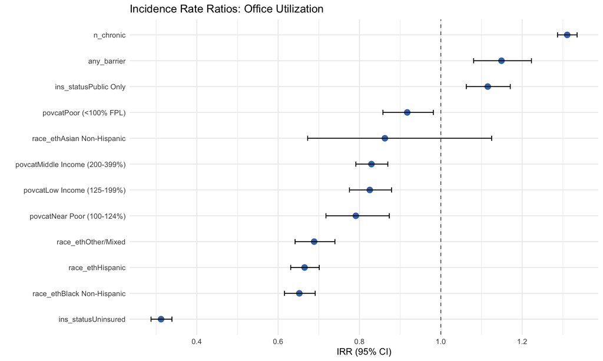

```r
# Forest plot for office visits
office_tidy %>%
  filter(str_detect(term, "ins_status|povcat|race_eth|any_barrier|n_chronic")) %>%
  ggplot(aes(x = IRR, y = reorder(term, IRR))) +
  geom_point(size = 3, color = "#4575B4") +
  geom_errorbarh(aes(xmin = CI_low, xmax = CI_high), height = 0.2) +
  geom_vline(xintercept = 1, linetype = "dashed", color = "grey40") +
  labs(title = "Incidence Rate Ratios: Office Utilization",
       x = "IRR (95% CI)", y = "") +
  theme_minimal()
```

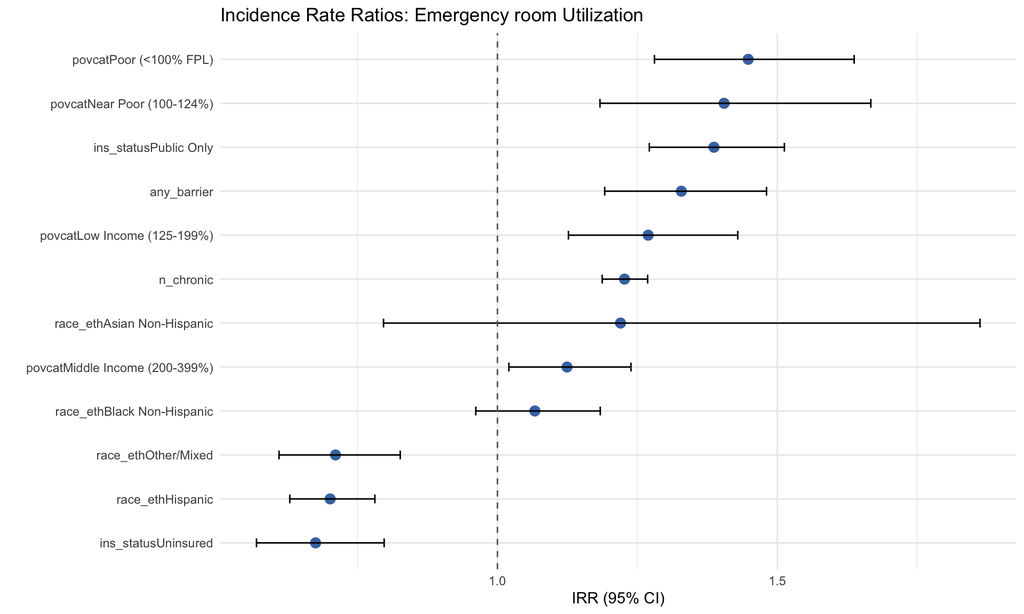

```r
# Forest plot for er visits
er_tidy %>%
  filter(str_detect(term, "ins_status|povcat|race_eth|any_barrier|n_chronic")) %>%
  ggplot(aes(x = IRR, y = reorder(term, IRR))) +
  geom_point(size = 3, color = "#4575B4") +
  geom_errorbarh(aes(xmin = CI_low, xmax = CI_high), height = 0.2) +
  geom_vline(xintercept = 1, linetype = "dashed", color = "grey40") +
  labs(title = "Incidence Rate Ratios: Emergency room Utilization",
       x = "IRR (95% CI)", y = "") +
  theme_minimal()
```

```r
# Model fit summary table
fit_table <- tibble(
  Model     = c("Poisson (Office)", "NB (Office)",
                "Poisson (ER)",    "NB (ER)"),
  AIC       = c(round(AIC(pois_model_office),        1),
                round(AIC(model_nb_office),   1),
                round(AIC(pois_model_er),     1),
                round(AIC(model_nb_er),       1)),
  Deviance  = c(round(deviance(pois_model_office),       1),
                round(deviance(model_nb_office),  1),
                round(deviance(pois_model_er),    1),
                round(deviance(model_nb_er),      1)),
  Theta     = c("—",
                round(model_nb_office$theta, 3),
                "—",
                round(model_nb_er$theta,     3))
)

knitr::kable(fit_table,
             caption = "Model Fit Summary: Poisson vs. Negative Binomial")
```

Model Fit Summary: Poisson vs. Negative Binomial

| Model | AIC | Deviance | Theta |
| --- | --- | --- | --- |
| Poisson (Office) | 298227.7 | 241922.9 | — |
| NB (Office) | 119821.7 | 23430.4 | 0.613 |
| Poisson (ER) | 25555.6 | 17749.6 | — |
| NB (ER) | 23737.4 | 10693.1 | 0.502 |

## Hidden Exclusion Analysis

Why we talk about Hidden Exclusion Analysis?

Poor health is strongly associated with greater use of office-based care (IRR = 1.687, z = 18.4, p < 2e−16), indicating that individuals who perceive their health as poor make approximately 69% more visits than those reporting better health. However, insurance status exerts an even larger influence on utilization. Uninsured individuals have an IRR of 0.312 (z = −27.6, p < 0.001), implying a 69% reduction in expected office visits after controlling for health status, age, income, education, and race. The coexistence of these two findings suggests the presence of hidden exclusion: although poor health increases the need for medical care, lack of insurance substantially suppresses the translation of need into actual service use. In other words, some individuals with high clinical need appear to remain outside the healthcare system because financial and coverage barriers prevent access to care.

```r
hidden_df <- meps_adults %>%
  group_by(any_barrier, any_chronic) %>%
  summarise(
    avg_office = round(mean(office_visits, na.rm = TRUE), 1),
    avg_er     = round(mean(er_visits, na.rm = TRUE), 2),
    n          = n(),
    .groups    = "drop"
  ) %>%
  mutate(
    Group = case_when(
      any_barrier == 0 & any_chronic == 0 ~ "No Barrier / No Chronic",
      any_barrier == 0 & any_chronic == 1 ~ "No Barrier / Chronic",
      any_barrier == 1 & any_chronic == 0 ~ "Barrier / No Chronic",
      any_barrier == 1 & any_chronic == 1 ~ "Barrier + Chronic"
    )
  )

knitr::kable(hidden_df,
             caption = "Average Utilization: Barriers × Chronic Status",
             col.names = c("Barrier", "Chronic", "Avg Office Visits", "Avg ER Visits", "N", "Group")) %>%
  kable_styling()
```

Average Utilization: Barriers × Chronic Status

| Barrier | Chronic | Avg Office Visits | Avg ER Visits | N | Group |
| --- | --- | --- | --- | --- | --- |
| 0 | 0 | 4.0 | 0.13 | 8906 | No Barrier / No Chronic |
| 0 | 1 | 10.6 | 0.32 | 10139 | No Barrier / Chronic |
| 1 | 0 | 4.6 | 0.25 | 1052 | Barrier / No Chronic |
| 1 | 1 | 9.8 | 0.43 | 1270 | Barrier + Chronic |

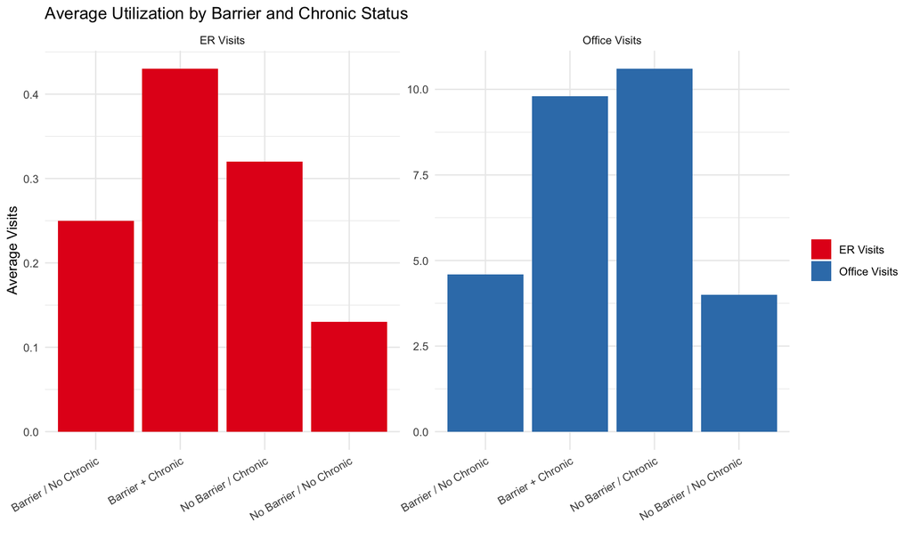

```r
hidden_df %>%
  pivot_longer(cols = c(avg_office, avg_er),
               names_to = "type", values_to = "average") %>%
  mutate(type = ifelse(type == "avg_office", "Office Visits", "ER Visits")) %>%
  ggplot(aes(x = Group, y = average, fill = type)) +
  geom_col(position = "dodge") +
  facet_wrap(~type, scales = "free_y")+
  scale_fill_brewer(palette = "Set1", name = "") +
  labs(title = "Average Utilization by Barrier and Chronic Status",
       x = "", y = "Average Visits") +
  theme_minimal() +
  theme(axis.text.x = element_text(angle = 30, hjust = 1))
```

The code groups all patients into four cells defined by two binary variables: any_barrier (has at least one access barrier) and any_chronic (has at least one chronic condition). For each cell, it computes the mean office visits and mean ER visits.

The critical contrast is between the two chronic condition groups:

•*No Barrier and Chronic*: patients with chronic conditions who have access to care. Office visits are high; ER visits are moderate.

•*Barrier and Chronic*: patients with the same clinical profile but structural barriers. Office visits are quite lower than before, because of they cannot access care. ER visits are higher, the emergency department becomes the residual access point for unmet primary care need. They make only 9.8 outpatient visits, compared to 10.6 for the group with the same condition but without barriers. They have the same clinical need, yet make fewer visits. And, most importantly, they visit the emergency room 0.43 times on average, the highest rate of all the groups.

A key point lies in the size of the groups. The “Barrier + Chronic” group comprises only 1,270 people out of 21,218 (about 6% of the sample). Yet this small group has the highest rate of ER visits of all (0.43) and fewer office visits than those with the same clinical profile but without barriers. This is significant because it shows that hidden exclusion is concentrated in this specific and distinct sub-group.

# Generalized Linear Mixed Models

In both the Logistic Regression and Negative Binomial Regression models, region and ins_status were specified as fixed effects, allowing the estimation of category-specific coefficients relative to a reference group.This specification is appropriate when the objective is to interpret how each category compares to a baseline, making it suitable for examining regional differences and variations across insurance status groups.

A Generalized Linear Mixed Model (GLMM) with either variable as a random effect asks a fundamentally different question: not how a specific group differs from the reference, but how much unexplained variability in healthcare utilization exists at the group level, beyond what individual-level predictors already capture.

## GLMM: Region as Random Effect (Office Visits)

```r
theta_office <- model_nb_office$theta

glmm_office <- glmer( office_visits ~ ins_status + age_group + sex + race_eth + povcat +
    n_chronic + poor_health + educ_cat + any_barrier + (1 | region),
  family  = negative.binomial(theta = theta_office),
  data    = meps_adults,
  control = glmerControl(optimizer = "bobyqa", optCtrl = list(maxfun = 1e5)))

summary(glmm_office)
```

```
## Generalized linear mixed model fit by maximum likelihood (Laplace
##   Approximation) [glmerMod]
##  Family: Negative Binomial(0.6127)  ( log )
## Formula: office_visits ~ ins_status + age_group + sex + race_eth + povcat +
##     n_chronic + poor_health + educ_cat + any_barrier + (1 | region)
##    Data: meps_adults
## Control: glmerControl(optimizer = "bobyqa", optCtrl = list(maxfun = 1e+05))
##
##       AIC       BIC    logLik -2*log(L)  df.resid
##  119835.0  120026.1  -59893.5  119787.0     21194
##
## Scaled residuals:
##    Min     1Q Median     3Q    Max
## -0.778 -0.643 -0.425  0.048 96.346
##
## Random effects:
##  Groups Name        Variance Std.Dev.
##  region (Intercept) 0.00977  0.09884
## Number of obs: 21218, groups:  region, 4
##
## Fixed effects:
##                                 Estimate Std. Error z value Pr(>|z|)
## (Intercept)                     1.171899   0.072853  16.086  < 2e-16 ***
## ins_statusPublic Only           0.109914   0.024723   4.446 8.76e-06 ***
## ins_statusUninsured            -1.165150   0.041897 -27.810  < 2e-16 ***
## age_group35-49                  0.161404   0.027842   5.797 6.74e-09 ***
## age_group50-64                  0.186400   0.029076   6.411 1.45e-10 ***
## age_group65+                    0.376731   0.032428  11.617  < 2e-16 ***
## sexFemale                       0.384525   0.018916  20.328  < 2e-16 ***
## race_ethBlack Non-Hispanic     -0.428807   0.029493 -14.540  < 2e-16 ***
## race_ethHispanic               -0.407999   0.026880 -15.179  < 2e-16 ***
## race_ethAsian Non-Hispanic     -0.147940   0.130956  -1.130   0.2586
## race_ethOther/Mixed            -0.373024   0.036210 -10.302  < 2e-16 ***
## povcatPoor (<100% FPL)         -0.086826   0.034442  -2.521   0.0117 *
## povcatNear Poor (100-124%)     -0.234749   0.050088  -4.687 2.78e-06 ***
## povcatLow Income (125-199%)    -0.192110   0.031955  -6.012 1.83e-09 ***
## povcatMiddle Income (200-399%) -0.187424   0.024180  -7.751 9.10e-15 ***
## n_chronic                       0.270355   0.009368  28.860  < 2e-16 ***
## poor_health                     0.522857   0.028098  18.608  < 2e-16 ***
## educ_catSome HS                 0.020956   0.051789   0.405   0.6857
## educ_catHS Grad                 0.036717   0.046084   0.797   0.4256
## educ_catSome College            0.251673   0.047419   5.307 1.11e-07 ***
## educ_catCollege+                0.390431   0.047817   8.165 3.21e-16 ***
## any_barrier                     0.138664   0.031523   4.399 1.09e-05 ***
## ---
## Signif. codes:  0 '***' 0.001 '**' 0.01 '*' 0.05 '.' 0.1 ' ' 1
```

```r
vc_office <- as.data.frame(lme4::VarCorr(glmm_office))
icc_office <- vc_office$vcov[1] / (vc_office$vcov[1] + (pi^2 / 3))

cat("Region Random-Effect Variance:", round(vc_office$vcov[1], 4), "\n")
```

```
## Region Random-Effect Variance: 0.0098
```

```r
cat("Intraclass Correlation (ICC):", round(icc_office, 4), "\n\n")
```

```
## Intraclass Correlation (ICC): 0.003
```

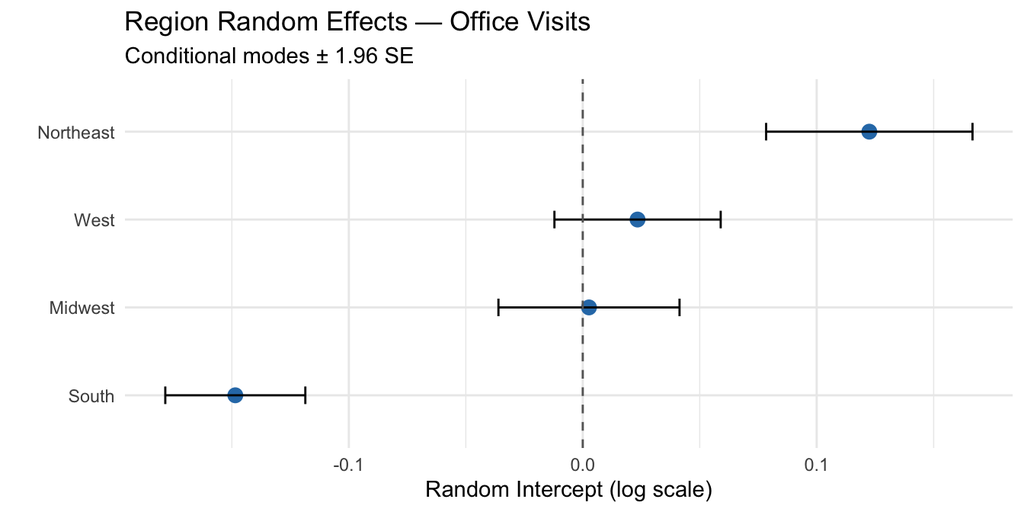

```
## Marginal R²:  0.265
```

```
## Conditional R² :  0.2691
```

```
## AIC NB fixed-effect model:  119821.7
```

```
## AIC GLMM - region random:  119835
```

```r
ranef_df <- as.data.frame(lme4::ranef(glmm_office, condVar = TRUE)$region) %>%
  tibble::rownames_to_column("region") %>%
  rename(intercept = `(Intercept)`)

condvar <- attr(lme4::ranef(glmm_office, condVar = TRUE)$region, "postVar")
ranef_df$se <- sqrt(condvar[1, 1, ])

ggplot(ranef_df, aes(x = reorder(region, intercept), y = intercept)) +
  geom_point(size = 3, color = "#2C7BB6") +
  geom_errorbar(aes(ymin = intercept - 1.96 * se,
                    ymax = intercept + 1.96 * se), width = 0.2) +
  geom_hline(yintercept = 0, linetype = "dashed", color = "grey40") +
  coord_flip() +
  labs(title = "Region Random Effects — Office Visits", subtitle = "Conditional modes ± 1.96 SE",
       x = "", y = "Random Intercept (log scale)") +
  theme_minimal()
```

The marginal R² of 0.265 rises to just 0.269 when the regional random effect is added; an increment of 0.004 that confirms geography contributes almost nothing beyond what insurance status, income, age, health status, and education already capture.

The AIC comparison reinforces this conclusion: the fixed-effect Negative Binomial model from the previous part (AIC = 119,822) outperforms the GLMM (AIC = 119,835). The fixed-effect specification remains the preferred model for office visit counts.

## GLMM: Region as Random Effect (ER Visits)

```r
theta_er <- model_nb_er$theta

glmm_er <- glmer(er_visits ~ ins_status + age_group + sex + race_eth + povcat +
    n_chronic + poor_health + educ_cat + any_barrier +(1 | region),
  family = negative.binomial(theta = theta_er),
  data = meps_adults,
  control = glmerControl(optimizer = "bobyqa", optCtrl = list(maxfun = 1e5) ))

summary(glmm_er)
```

```
## Generalized linear mixed model fit by maximum likelihood (Laplace
##   Approximation) [glmerMod]
##  Family: Negative Binomial(0.5021)  ( log )
## Formula: er_visits ~ ins_status + age_group + sex + race_eth + povcat +
##     n_chronic + poor_health + educ_cat + any_barrier + (1 | region)
##    Data: meps_adults
## Control: glmerControl(optimizer = "bobyqa", optCtrl = list(maxfun = 1e+05))
##
##       AIC       BIC    logLik -2*log(L)  df.resid
##   23741.4   23932.5  -11846.7   23693.4     21194
##
## Scaled residuals:
##     Min      1Q  Median      3Q     Max
## -0.6511 -0.3890 -0.3235 -0.2696 26.9044
##
## Random effects:
##  Groups Name        Variance Std.Dev.
##  region (Intercept) 0.002203 0.04694
## Number of obs: 21218, groups:  region, 4
##
## Fixed effects:
##                                 Estimate Std. Error z value Pr(>|z|)
## (Intercept)                    -2.342764   0.105979 -22.106  < 2e-16 ***
## ins_statusPublic Only           0.326706   0.044273   7.379 1.59e-13 ***
## ins_statusUninsured            -0.392460   0.085785  -4.575 4.76e-06 ***
## age_group35-49                 -0.100960   0.057127  -1.767  0.07718 .
## age_group50-64                 -0.162029   0.059378  -2.729  0.00636 **
## age_group65+                   -0.008848   0.064378  -0.137  0.89069
## sexFemale                       0.226495   0.037029   6.117 9.56e-10 ***
## race_ethBlack Non-Hispanic      0.060913   0.052619   1.158  0.24702
## race_ethHispanic               -0.367446   0.055567  -6.613 3.77e-11 ***
## race_ethAsian Non-Hispanic      0.190811   0.215901   0.884  0.37681
## race_ethOther/Mixed            -0.351172   0.077600  -4.525 6.03e-06 ***
## povcatPoor (<100% FPL)          0.372464   0.062657   5.945 2.77e-09 ***
## povcatNear Poor (100-124%)      0.341460   0.087420   3.906 9.39e-05 ***
## povcatLow Income (125-199%)     0.240765   0.060632   3.971 7.16e-05 ***
## povcatMiddle Income (200-399%)  0.118002   0.049402   2.389  0.01691 *
## n_chronic                       0.204822   0.016866  12.144  < 2e-16 ***
## poor_health                     0.882357   0.044285  19.924  < 2e-16 ***
## educ_catSome HS                 0.384472   0.092480   4.157 3.22e-05 ***
## educ_catHS Grad                 0.211103   0.085193   2.478  0.01321 *
## educ_catSome College            0.196228   0.088394   2.220  0.02642 *
## educ_catCollege+               -0.056074   0.091339  -0.614  0.53927
## any_barrier                     0.283596   0.055380   5.121 3.04e-07 ***
## ---
## Signif. codes:  0 '***' 0.001 '**' 0.01 '*' 0.05 '.' 0.1 ' ' 1
```

```r
vc_er   <- as.data.frame(lme4::VarCorr(glmm_er))
icc_er  <- vc_er$vcov[1] / (vc_er$vcov[1] + (pi^2 / 3))

cat("Region Random-effect variance:", round(vc_er$vcov[1], 4), "\n")
```

```
## Region Random-effect variance: 0.0022
```

```r
cat("Intraclass Correlation (ICC):", round(icc_er, 4), "\n\n")
```

```
## Intraclass Correlation (ICC): 7e-04
```

```
## Marginal R²:    0.0743
```

```
## Conditional R²: 0.0746
```

```
## AIC NB fixed-effect model: 23737.4
```

```
## AIC GLMM - region random:  23741.4
```

Taken together, the two GLMM models for region deliver a consistent and substantively important message: the structural disparities in healthcare utilization documented in the previous part are a national phenomenon, not a regional one. The South does not produce more hidden exclusion than the Northeast because it is in the South; it does so because it concentrates more uninsured, lower-income, and higher-barrier individuals.

## GLMM: Insurance Status as Random Effect (Office Visits)

```r
theta_office <- model_nb_office$theta

glmm_ins_office <- glmer(
  office_visits ~ region + age_group + sex + race_eth + povcat +
    n_chronic + poor_health + educ_cat + any_barrier + (1 | ins_status),
  family  = negative.binomial(theta = theta_office),
  data    = meps_adults,
  control = glmerControl(optimizer = "bobyqa", optCtrl = list(maxfun = 1e5))
)

summary(glmm_ins_office)
```

```
## Generalized linear mixed model fit by maximum likelihood (Laplace
##   Approximation) [glmerMod]
##  Family: Negative Binomial(0.6127)  ( log )
## Formula: office_visits ~ region + age_group + sex + race_eth + povcat +
##     n_chronic + poor_health + educ_cat + any_barrier + (1 | ins_status)
##    Data: meps_adults
## Control: glmerControl(optimizer = "bobyqa", optCtrl = list(maxfun = 1e+05))
##
##       AIC       BIC    logLik -2*log(L)  df.resid
##  119843.0  120042.0  -59896.5  119793.0     21193
##
## Scaled residuals:
##    Min     1Q Median     3Q    Max
## -0.778 -0.643 -0.425  0.049 95.884
##
## Random effects:
##  Groups     Name        Variance Std.Dev.
##  ins_status (Intercept) 0.3306   0.575
## Number of obs: 21218, groups:  ins_status, 3
##
## Fixed effects:
##                                 Estimate Std. Error z value Pr(>|z|)
## (Intercept)                     0.949947   0.334499   2.840 0.004513 **
## regionMidwest                  -0.126701   0.031025  -4.084 4.43e-05 ***
## regionSouth                    -0.281948   0.028256  -9.978  < 2e-16 ***
## regionWest                     -0.105039   0.030108  -3.489 0.000485 ***
## age_group35-49                  0.161351   0.027842   5.795 6.82e-09 ***
## age_group50-64                  0.186451   0.029075   6.413 1.43e-10 ***
## age_group65+                    0.377405   0.032427  11.639  < 2e-16 ***
## sexFemale                       0.384997   0.018915  20.354  < 2e-16 ***
## race_ethBlack Non-Hispanic     -0.427466   0.029498 -14.491  < 2e-16 ***
## race_ethHispanic               -0.408346   0.026889 -15.187  < 2e-16 ***
## race_ethAsian Non-Hispanic     -0.147948   0.130928  -1.130 0.258478
## race_ethOther/Mixed            -0.373053   0.036224 -10.299  < 2e-16 ***
## povcatPoor (<100% FPL)         -0.086199   0.034440  -2.503 0.012318 *
## povcatNear Poor (100-124%)     -0.234458   0.050090  -4.681 2.86e-06 ***
## povcatLow Income (125-199%)    -0.192138   0.031955  -6.013 1.82e-09 ***
## povcatMiddle Income (200-399%) -0.187041   0.024181  -7.735 1.03e-14 ***
## n_chronic                       0.270583   0.009367  28.886  < 2e-16 ***
## poor_health                     0.523024   0.028098  18.614  < 2e-16 ***
## educ_catSome HS                 0.020946   0.051771   0.405 0.685785
## educ_catHS Grad                 0.036609   0.046066   0.795 0.426793
## educ_catSome College            0.251557   0.047401   5.307 1.11e-07 ***
## educ_catCollege+                0.390320   0.047798   8.166 3.19e-16 ***
## any_barrier                     0.138387   0.031521   4.390 1.13e-05 ***
## ---
## Signif. codes:  0 '***' 0.001 '**' 0.01 '*' 0.05 '.' 0.1 ' ' 1
```

```r
vc_ins_office <- as.data.frame(lme4::VarCorr(glmm_ins_office))
icc_ins_office <- vc_ins_office$vcov[1] / (vc_ins_office$vcov[1] + (pi^2 / 3))

cat("Insurance Status Random-effect variance:", round(vc_ins_office$vcov[1], 4), "\n")
```

```
## Insurance Status Random-effect variance: 0.3306
```

```r
cat("Intraclass Correlation (ICC):", round(icc_ins_office, 4), "\n\n")
```

```
## Intraclass Correlation (ICC): 0.0913
```

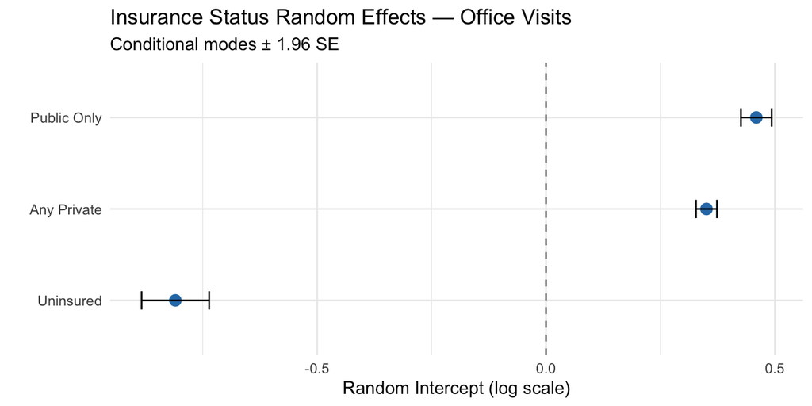

```
## Marginal R² :   0.1698
```

```
## Conditional R² :    0.2997
```

```
## AIC NB fixed-effect model:        119821.7
```

```
## AIC GLMM- insurance random:      119843
```

```r
ranef_ins_df <- as.data.frame(lme4::ranef(glmm_ins_office, condVar = TRUE)$ins_status) %>%
  tibble::rownames_to_column("ins_status") %>%
  rename(intercept = `(Intercept)`)

condvar_ins <- attr(lme4::ranef(glmm_ins_office, condVar = TRUE)$ins_status, "postVar")
ranef_ins_df$se <- sqrt(condvar_ins[1, 1, ])

ggplot(ranef_ins_df, aes(x = reorder(ins_status, intercept), y = intercept)) +
  geom_point(size = 3, color = "#2C7BB6") +
  geom_errorbar(aes(ymin = intercept - 1.96 * se,
                    ymax = intercept + 1.96 * se), width = 0.2) +
  geom_hline(yintercept = 0, linetype = "dashed", color = "grey40") +
  coord_flip() +
  labs(title = "Insurance Status Random Effects — Office Visits ",
       subtitle = "Conditional modes ± 1.96 SE",
       x = "", y = "Random Intercept (log scale)") +
  theme_minimal()
```

The random-effect variance for insurance status is 0.3306, approximately 9.1% of the residual variability in office visit counts is attributable to systematic differences between insurance categories. The conditional R² rises from 0.170 to 0.300 once the random intercept is included, confirming that insurance status carries genuine grouping-level variance beyond what income, age, health status, education, and geography already account for.

The AIC comparison, however, presents a more complex picture. The GLMM (AIC = 119,843) is worse than the fixed-effect Negative Binomial model (AIC = 119,822). This means that treating insurance status as a random effect, with only three levels, is a less efficient parameterisation than including it as a fixed predictor with explicit, estimable coefficients.

## GLMM: Insurance Status as Random Effect (ER Visits)

```r
theta_er <- model_nb_er$theta

glmm_ins_er <- glmer( er_visits ~ region + age_group + sex + race_eth + povcat +
    n_chronic + poor_health + educ_cat + any_barrier +(1 | ins_status),
  family = MASS::negative.binomial(theta = theta_er),
  data = meps_adults,
  control = glmerControl( optimizer = "bobyqa", optCtrl = list(maxfun = 1e5) ))

summary(glmm_ins_er)
```

```
## Generalized linear mixed model fit by maximum likelihood (Laplace
##   Approximation) [glmerMod]
##  Family: Negative Binomial(0.5021)  ( log )
## Formula:
## er_visits ~ region + age_group + sex + race_eth + povcat + n_chronic +
##     poor_health + educ_cat + any_barrier + (1 | ins_status)
##    Data: meps_adults
## Control: glmerControl(optimizer = "bobyqa", optCtrl = list(maxfun = 1e+05))
##
##       AIC       BIC    logLik -2*log(L)  df.resid
##   23750.7   23949.8  -11850.4   23700.7     21193
##
## Scaled residuals:
##     Min      1Q  Median      3Q     Max
## -0.6527 -0.3890 -0.3236 -0.2696 26.4996
##
## Random effects:
##  Groups     Name        Variance Std.Dev.
##  ins_status (Intercept) 0.08171  0.2858
## Number of obs: 21218, groups:  ins_status, 3
##
## Fixed effects:
##                                Estimate Std. Error z value Pr(>|z|)
## (Intercept)                    -2.36682    0.19961 -11.857  < 2e-16 ***
## regionMidwest                   0.10169    0.05892   1.726  0.08437 .
## regionSouth                    -0.01545    0.05501  -0.281  0.77880
## regionWest                     -0.06662    0.05960  -1.118  0.26368
## age_group35-49                 -0.10120    0.05711  -1.772  0.07641 .
## age_group50-64                 -0.16152    0.05937  -2.720  0.00652 **
## age_group65+                   -0.00558    0.06438  -0.087  0.93093
## sexFemale                       0.22734    0.03704   6.138 8.37e-10 ***
## race_ethBlack Non-Hispanic      0.06509    0.05308   1.226  0.22008
## race_ethHispanic               -0.35707    0.05522  -6.466 1.00e-10 ***
## race_ethAsian Non-Hispanic      0.19943    0.21598   0.923  0.35579
## race_ethOther/Mixed            -0.34124    0.07752  -4.402 1.07e-05 ***
## povcatPoor (<100% FPL)          0.37116    0.06264   5.926 3.11e-09 ***
## povcatNear Poor (100-124%)      0.34164    0.08741   3.908 9.29e-05 ***
## povcatLow Income (125-199%)     0.23880    0.06062   3.939 8.17e-05 ***
## povcatMiddle Income (200-399%)  0.11735    0.04941   2.375  0.01754 *
## n_chronic                       0.20520    0.01688  12.160  < 2e-16 ***
## poor_health                     0.88247    0.04429  19.927  < 2e-16 ***
## educ_catSome HS                 0.38440    0.09241   4.160 3.18e-05 ***
## educ_catHS Grad                 0.21087    0.08513   2.477  0.01325 *
## educ_catSome College            0.19946    0.08836   2.257  0.02398 *
## educ_catCollege+               -0.05394    0.09129  -0.591  0.55461
## any_barrier                     0.28069    0.05540   5.067 4.05e-07 ***
## ---
## Signif. codes:  0 '***' 0.001 '**' 0.01 '*' 0.05 '.' 0.1 ' ' 1
```

```r
vc_ins_er   <- as.data.frame(lme4::VarCorr(glmm_ins_er))
icc_ins_er  <- vc_ins_er$vcov[1] / (vc_ins_er$vcov[1] + (pi^2 / 3))

cat("Insurance Status Random-effect variance:", round(vc_ins_er$vcov[1], 4), "\n")
```

```
## Insurance Status Random-effect variance: 0.0817
```

```r
cat("Intraclass Correlation (ICC):", round(icc_ins_er, 4), "\n\n")
```

```
## Intraclass Correlation (ICC): 0.0242
```

```r
r2_glmm_ins_er <- MuMIn::r.squaredGLMM(glmm_ins_er)
cat("Marginal R²:   ", round(r2_glmm_ins_er[1, "R2m"], 4), "\n")
```

```
## Marginal R²:    0.0575
```

```r
cat("Conditional R²:", round(r2_glmm_ins_er[1, "R2c"], 4), "\n")
```

```
## Conditional R²: 0.0699
```

```r
cat("AIC NB fixed-effect model:", round(AIC(model_nb_er), 1), "\n")
```

```
## AIC NB fixed-effect model: 23737.4
```

```r
cat("AIC GLMM - insurance random: ", round(AIC(glmm_ins_er), 1), "\n")
```

```
## AIC GLMM - insurance random:  23750.7
```

For emergency department visits, the random-effect variance for insurance status is 0.0817, yielding an ICC of 0.024, substantially lower than the office visit ICC (9.1%). This result is consistent with the structural logic from the Negative Binomial Regression: insurance status primarily gates entry into the ambulatory circuit, while emergency access is less contingent on coverage type.  
The marginal and conditional R² differ by just 1.2 percentage points (0.058 and 0.070), and the GLMM (AIC = 23,751) is again worse than the fixed-effect NB model (AIC = 23,737) by 14 points.  
The fixed-effect IRRs replicate the Negative Binomial Regression with full stability.

The GLMM analysis confirms that the structural disparities documented in this analysis are properties of individual circumstances, not of geography or institutional context.

# Conclusions

Our analysis confirmed that barriers are real and measurable.

Taken together, our results demonstrate that in the United States, healthcare access is not purely a function of clinical need. Insurance coverage and income act as gatekeeping mechanisms that redirect, or entirely suppress, utilization.